### “Unheard Echoes to Rising Voices: Understanding the Shift in Crime Reporting”

### “Post-Nirbhaya Case”

*Objective : Estimate the causal effect of the 2012 Nirbhaya Brutal Gang Rape case, which led to an International Uproar about women safety, and a modification in law on crimes against women, by comparing the actual post-2012 trends to a synthetic counterfactuals constructed from other potential predictors, Literacy Rate, Per Capita Income & Prices constant and current).*

*Note: The collected data was not enough to perform the estimates at a actual level due to additional predictor data being missing (not freely available on the website), and also due to different reporting standards through the time.*

The below study represents the way on how to actually perform the DID estimates using the synthetic control, and falsification tests also.

Author: Akash Mittal ; Matricola ID: 31909A ;Data Science for Economics | University of Milan, Italy

### Loading the required Libraries

```r
#install.packages(c("Synth", "tidyverse", "readxl"))
library(Synth) # package for Synthetic Control
library(tidyverse)
library(readxl)
library(glmnet)
```

```r
library(dplyr)
library(ggplot2)
library(SCtools)
```

### Loading and Preparing the Data

```r
# Load crimes against women data
crimes_women <- read_excel("Master Sheet.xlsx", sheet='Women')

# Load murder data
murders <- read_excel("Master Sheet.xlsx", sheet='Murders')

# Load the Estimated Population Data for different states
population <- read_excel("India_Population_Estiamtes.xlsx")

# Loading the Predictors Dataset
predictor_df <- read_excel("predictor_data.xlsx")

# Loading the Accidents Dataset
accidents_long <- read_excel("accidents_data.xlsx")
```

Having a look at the data-sets after loading

```r
# Checking the data structure
str(crimes_women)
```

```
## tibble [175 × 17] (S3: tbl_df/tbl/data.frame)
##  $ STATE/UT  : chr [1:175] "Chandigarh" "Chandigarh" "Chandigarh" "Chandigarh" ...
##  $ CRIME HEAD: chr [1:175] "RAPE" "Kidnapping & Abduction of Women & Grils" "ASSAULT ON WOMEN WITH INTENT TO OUTRAGE HER MODESTY" "INSULT TO THE MODESTY OF WOMEN" ...
##  $ 2001      : num [1:175] 18 50 24 15 36 381 964 502 90 138 ...
##  $ 2002      : num [1:175] 18 47 36 28 56 403 893 446 128 135 ...
##  $ 2003      : num [1:175] 18 28 11 4 93 ...
##  $ 2004      : num [1:175] 19 43 20 18 73 ...
##  $ 2005      : num [1:175] 33 45 31 9 75 ...
##  $ 2006      : num [1:175] 19 57 20 13 102 ...
##  $ 2007      : num [1:175] 22 46 32 11 112 ...
##  $ 2008      : num [1:175] 20 42 19 2 49 ...
##  $ 2009      : num [1:175] 29 36 26 2 51 ...
##  $ 2010      : num [1:175] 31 28 29 4 41 ...
##  $ 2011      : num [1:175] 27 46 21 12 46 ...
##  $ 2012      : num [1:175] 27 66 45 25 73 ...
##  $ 2013      : num [1:175] 45 174 143 26 92 ...
##  $ 2014      : num [1:175] 118 266 174 4 282 ...
##  $ 2015      : num [1:175] 144 330 152 20 252 ...
```

```r
str(population)
```

```
## tibble [35 × 17] (S3: tbl_df/tbl/data.frame)
##  $ State/UT               : chr [1:35] "Jammu & Kashmir" "Himachal Pradesh" "Punjab" "Chandigarh" ...
##  $ 2001                   : num [1:35] 10143700 6077900 24358999 900635 8489349 ...
##  $ 2002                   : num [1:35] 10361223 6152332 24677966 915035 8636944 ...
##  $ 2003                   : num [1:35] 10583411 6227675 25001110 929665 8787105 ...
##  $ 2004                   : num [1:35] 10810363 6303941 25328485 944529 8939877 ...
##  $ 2005                   : num [1:35] 11042182 6381141 25660147 959631 9095305 ...
##  $ 2006                   : num [1:35] 11278972 6459286 25996152 974974 9253435 ...
##  $ 2007                   : num [1:35] 11520840 6538388 26336557 990563 9414314 ...
##  $ 2008                   : num [1:35] 11767895 6618459 26681419 1006401 9577990 ...
##  $ 2009                   : num [1:35] 12020247 6699510 27030797 1022492 9744512 ...
##  $ 2010                   : num [1:35] 12278011 6781554 27384750 1038840 9913929 ...
##  $ 2011                   : num [1:35] 12541302 6864602 27743338 1055450 10086292 ...
##  $ 2012                   : num [1:35] 12810239 6948668 28106621 1072325 10261651 ...
##  $ 2013                   : num [1:35] 13084944 7033763 28474661 1089470 10440059 ...
##  $ 2014                   : num [1:35] 13365539 7119900 28847520 1106889 10621569 ...
##  $ 2015                   : num [1:35] 13652152 7207092 29225262 1124587 10806235 ...
##  $ Growth_Rates_percentage: num [1:35] 0.0214 0.0122 0.0131 0.016 0.0174 ...
```

```r
str(murders)
```

```
## tibble [525 × 3] (S3: tbl_df/tbl/data.frame)
##  $ STATE: chr [1:525] "Bihar" "Bihar" "Bihar" "Bihar" ...
##  $ YEAR : num [1:525] 2001 2002 2003 2004 2005 ...
##  $ Cases: num [1:525] 3643 3712 3771 3948 3471 ...
```

```r
str(predictor_df)
```

```
## tibble [2,401 × 4] (S3: tbl_df/tbl/data.frame)
##  $ State    : chr [1:2401] "Andhra Pradesh" "Arunachal Pradesh" "Assam" "Bihar" ...
##  $ Predictor: chr [1:2401] "SDP_Growth Rate" "SDP_Growth Rate" "SDP_Growth Rate" "SDP_Growth Rate" ...
##  $ Year     : num [1:2401] 1997 1997 1997 1997 1997 ...
##  $ Value    : num [1:2401] -1.37 3.12 0.99 -3.85 3.11 2.82 2.11 1.43 6.38 5.66 ...
```

```r
str(accidents_long)
```

```
## tibble [555 × 4] (S3: tbl_df/tbl/data.frame)
##  $ States/UTs: chr [1:555] "Andhra Pradesh" "Arunachal Pradesh" "Assam" "Bihar" ...
##  $ Crime_Head: chr [1:555] "Total Accidents" "Total Accidents" "Total Accidents" "Total Accidents" ...
##  $ Year      : chr [1:555] "2001" "2001" "2001" "2001" ...
##  $ Value     : chr [1:555] "28485" "236" "2049" "5144" ...
```

```r
# Below code was used to check the names of States in different datasets, which were later standardized
#sort(unique(crimes_women$`STATE/UT`))
#sort(unique(population$`State/UT`))
#sort(unique(predictor_df$State))
#sort(unique(accidents_long$`States/UTs`))
```

Since, the State Names are different in different data-sets, standardizing them to maintain coherence.

```r
# crimes_women & population data-sets have same names (was standardized initially in Excel)

# Difference between the predictor and crime dataset in names -
name_mapping <- c(
  "Andaman and Nicobar Islands" = "A&N Islands",
  "Chattisgarh" = "Chhattisgarh",
  "Dadra and Nagar Haveli" = "D&N Haveli",
  "Daman and Diu" = "Daman & Diu",
  "Delhi" = "Delhi UT",
  "Jammu and Kashmir" = "Jammu & Kashmir",
  "Uttrakhand" = "Uttarakhand"
)

predictor_df$State <- ifelse(predictor_df$State %in% names(name_mapping),
                              name_mapping[predictor_df$State],
                              predictor_df$State)

# sort(unique(predictor_df$State))


# Similarly doing this for accidents_long dataset.
name_mapping_accidents <- c(
  "A & N ISLANDS" = "A&N Islands",
  "D & N HAVELI" = "D&N Haveli",
  "DAMAN & DIU" = "Daman & Diu",
  "DELHI (UT)" = "Delhi UT",
  "TOTAL (ALL INDIA)" = "India")

accidents_long$`States/UTs` <- ifelse(accidents_long$`States/UTs` %in% names(name_mapping_accidents),
                                      name_mapping_accidents[accidents_long$`States/UTs`],
                                      accidents_long$`States/UTs`)

# sort(unique(accidents_long$`States/UTs`))
```

Processing the Population Data (later to use for calculating Crimes per 100,000 people)

```r
population <- population %>%
  select(!Growth_Rates_percentage)

#summary(population)

# Reshape the population data to long format
population_long <- population %>%
  pivot_longer(cols = starts_with("20"),  # Select columns from 2001 to 2015
               names_to = "Year",          # Name the new column with years
               values_to = "Population") %>% # Name the new column with population values
               mutate(Year = as.numeric(Year))
```

Processing the Crimes Data to merge with Population Data.

```r
# head(crimes_women)

# Reshape the crimes data to long format
crimes_long <- crimes_women %>%
  gather(key = "Year", value = "crime_count", -`STATE/UT`, -`CRIME HEAD`) %>%
  mutate(Year = as.numeric(Year))  # Converting  before joining

crime_merged <- crimes_long %>%
  left_join(population_long, by = c("STATE/UT" = "State/UT", "Year" = "Year"))

crime_women_100k <- crime_merged %>%
  mutate(crime_rate_100k = ((crime_count / Population) * 100000)) %>%
  rename(State = `STATE/UT`, Crime_Head = `CRIME HEAD`, Value = crime_rate_100k) %>%
  select(-crime_count, -Population)
```

Processing the Murders Data

```r
# View(murders)
# its the long format as required
# str(murders)
murders_merged <- murders %>%
  left_join(population_long, by = c("STATE" = "State/UT", "YEAR" = "Year")) %>%
  mutate(year = as.numeric(YEAR)) %>%
  rename(Murders = Cases) %>%
  select(-year)

murders_100k <- murders_merged %>%
  mutate(murders_100k = ((Murders / Population) * 100000)) %>%
  rename(State = STATE, Year = YEAR) %>%
  select(-Murders, -Population) %>%
  mutate(Crime_Head = "MURDERS per 100k") %>%
  select(State, Crime_Head, Year, Value = murders_100k)
```

Process Accidents Data

```r
# Convert accidents to per 100k (FIX ADDED HERE)
accidents_long <- accidents_long %>%
  rename(State = `States/UTs`, Crime_Head = Crime_Head) %>%
  mutate(Year = as.numeric(Year),
         Value = as.numeric(Value)) %>%
  left_join(population_long, by = c("State" = "State/UT", "Year")) %>%
  mutate(Value = (Value / Population) * 100000) %>%
  select(-Population)
```

Combine All Dataset and performing the steps *Now, we combine the Predictors Data and then Accidents Data to this data-set, to have a combined data-frame with all available data, which will be convenient to use with Synth Package.*

*a) Combining the Predictors with the Crimes and Murders Data.* *b) Combining the Accidents Data.*

*Data for some predictors is only available 2004 onwards, so I dropped the data prior to 2004 and data after 2015 for analysis.*

*Note: If data for predictors is available for longer time frame, the estimates would be more accurate.*

The Whole Data Set Is Prepared for Final Analysis and next I convert it into Wide Format to be fed into the Synth Package for SCM control generation. Before that, I also did some descriptive analysis for different features about Delhi and overall average over other states.

```r
# Combine crimes and murders
crimes_with_murders <- crime_women_100k %>%
  bind_rows(murders_100k) %>%
  rename(Feature = Crime_Head)

# Adding predictors

# Filtering the data for Predictor with SDP_Growth Rate, as data is incomplete for that feature
predictor_df <- predictor_df %>%
  filter(Predictor != "SDP_Growth Rate")

crimes_with_murd_prd <- crimes_with_murders %>%
  bind_rows(predictor_df %>%
              rename(Feature = Predictor) %>%
              mutate(Feature = ifelse(is.na(Feature), "Other_Predictors", Feature)
                     )
            )

# Accidents data
accidents_long <- accidents_long %>%
  rename(Feature = Crime_Head) # Match column name


# Add accidents
df <- bind_rows(crimes_with_murd_prd, accidents_long)

# Filter years and remove unwanted states
df_filtered <- df %>%
  filter(Year >= 2004,
         Year <= 2015,
         !State %in% c("India", "Telangana"),
         !is.na(Feature))
```

```r
# Create Wide Format
df_mod <- df_filtered %>%
  pivot_wider(names_from = Feature, values_from = Value) %>%
  mutate(StateID = as.numeric(factor(State)))
```

```r
# Final dataset check
str(df_mod)
```

```
## tibble [420 × 13] (S3: tbl_df/tbl/data.frame)
##  $ State                                              : chr [1:420] "Chandigarh" "Delhi UT" "Haryana" "Madhya Pradesh" ...
##  $ Year                                               : num [1:420] 2004 2004 2004 2004 2004 ...
##  $ RAPE                                               : num [1:420] 2.01 3.76 1.73 4.51 1.54 ...
##  $ Kidnapping & Abduction of Women & Grils            : num [1:420] 4.553 6.004 1.308 0.915 1.228 ...
##  $ ASSAULT ON WOMEN WITH INTENT TO OUTRAGE HER MODESTY: num [1:420] 2.12 4.1 1.8 10.49 1.03 ...
##  $ INSULT TO THE MODESTY OF WOMEN                     : num [1:420] 1.906 0.886 3.807 1.26 0.15 ...
##  $ Cruelty by Husband or his relatives                : num [1:420] 7.73 8.55 9.07 5.39 3.16 ...
##  $ MURDERS per 100k                                   : num [1:420] 2.33 3.28 3.28 3.73 3.06 ...
##  $ Literacy Growth Rate                               : num [1:420] 83.2 83 70.1 65.4 71.5 ...
##  $ Per Capita Income_Current                          : num [1:420] 74173 63877 37972 15442 33103 ...
##  $ Per Capita Income_Constant                         : num [1:420] 74173 63877 37972 15442 33103 ...
##  $ Total Accidents                                    : num [1:420] 44.1 61.9 41.7 50.9 17.2 ...
##  $ StateID                                            : num [1:420] 6 10 13 20 28 29 33 34 15 5 ...
```

#### Generating the Descriptive Statistics for the pooled data

```r
# Function to create the descriptive summary of the dataset

summarize_feature <- function(df, feature_name) {
  df %>%
    summarize(
      Mean = mean(df[[feature_name]], na.rm = TRUE),
      Median = median(df[[feature_name]], na.rm = TRUE),
      Q1 = quantile(df[[feature_name]], 0.25, na.rm = TRUE),
      Q3 = quantile(df[[feature_name]], 0.75, na.rm = TRUE),
      Min = min(df[[feature_name]], na.rm = TRUE),
      Max = max(df[[feature_name]], na.rm = TRUE),
      SD = sd(df[[feature_name]], na.rm = TRUE),
      Missing = sum(is.na(df[[feature_name]]))
    )
}
```

Descriptive Statistics for Delhi over the years (2004-2015)

```r
df_mod_delhi <- df_mod %>%
  filter(State == "Delhi UT")

delhi_features <- names(df_mod_delhi)[3:13]

# Generate summaries
delhi_summary <- lapply(delhi_features, function(feature) {
  summary_result <- summarize_feature(df_mod_delhi, feature)
  summary_result$Feature <- feature  # Add the feature name to the summary result
  return(summary_result)
})

delhi_summaries_df <- bind_rows(delhi_summary)

delhi_summaries_df <- delhi_summaries_df %>%
  select(Feature, everything())

# print(delhi_summaries_df)


library(kableExtra)
library(knitr)
delhi_summaries_df %>%
  kable("html", caption = "Summary of Features for Delhi 2004-2015",
        digits = 4) %>%
  kable_styling(bootstrap_options = c("striped", "hover", "condensed"), full_width = F) %>%
  column_spec(1, bold = TRUE) %>%  # Bold the 'Feature' column
  add_header_above(c("Feature Summary" = ncol(delhi_summaries_df)))
```

Summary of Features for Delhi 2004-2015

| Feature Summary Feature | Feature Summary Mean | Feature Summary Median | Feature Summary Q1 | Feature Summary Q3 | Feature Summary Min | Feature Summary Max | Feature Summary SD | Feature Summary Missing |
| --- | --- | --- | --- | --- | --- | --- | --- | --- |
| RAPE | 7.4789 | 3.9663 | 3.3251 | 5.6435 | 2.9032 | 24.2574 | 7.8673 | 0 |
| Kidnapping & Abduction of Women & Grils | 16.2010 | 10.4054 | 7.3376 | 14.6375 | 6.0041 | 47.4449 | 14.6618 | 0 |
| ASSAULT ON WOMEN WITH INTENT TO OUTRAGE HER MODESTY | 13.8767 | 4.4783 | 3.8991 | 9.2248 | 3.4170 | 59.2041 | 19.3808 | 0 |
| INSULT TO THE MODESTY OF WOMEN | 3.8033 | 1.0196 | 0.8696 | 2.4407 | 0.4858 | 16.4584 | 5.7844 | 0 |
| Cruelty by Husband or his relatives | 14.8611 | 10.3569 | 8.7010 | 13.0452 | 7.9421 | 38.8406 | 10.7899 | 0 |
| MURDERS per 100k | 3.2209 | 3.2094 | 3.1023 | 3.3254 | 2.9634 | 3.4960 | 0.1689 | 0 |
| Literacy Growth Rate | 85.5282 | 85.5136 | 84.2507 | 86.7952 | 83.0063 | 88.0959 | 1.6682 | 0 |
| Per Capita Income_Current | 152780.0833 | 135532.5000 | 92249.5000 | 211151.0000 | 63877.0000 | 270261.0000 | 72102.0618 | 0 |
| Per Capita Income_Constant | 134182.2500 | 100572.0000 | 81493.0000 | 194340.5000 | 63877.0000 | 233115.0000 | 64440.6646 | 0 |
| Total Accidents | 50.4223 | 47.5052 | 43.9065 | 56.8351 | 40.5342 | 62.5143 | 8.0548 | 0 |
| StateID | 10.0000 | 10.0000 | 10.0000 | 10.0000 | 10.0000 | 10.0000 | 0.0000 | 0 |

Descriptive Statistics for Delhi over the years (2004-2012)

```r
df_mod_delhi_prior <- df_mod_delhi %>%
  filter(Year <= 2012)

# Generate summaries
delhi_summary_prior <- lapply(delhi_features, function(feature) {
  summary_result <- summarize_feature(df_mod_delhi_prior, feature)
  summary_result$Feature <- feature  # Add the feature name to the summary result
  return(summary_result)
})

delhi_summaries_df_prior <- bind_rows(delhi_summary_prior)

delhi_summaries_df_prior <- delhi_summaries_df_prior %>%
  select(Feature, everything())

# print(delhi_summaries_df)

delhi_summaries_df_prior %>%
  kable("html", caption = "Summary of Features for Delhi 2004-2012",
        digits = 4) %>%
  kable_styling(bootstrap_options = c("striped", "hover", "condensed"), full_width = F) %>%
  column_spec(1, bold = TRUE) %>%  # Bold the 'Feature' column
  add_header_above(c("Feature Summary" = ncol(delhi_summaries_df_prior)))
```

Summary of Features for Delhi 2004-2012

| Feature Summary Feature | Feature Summary Mean | Feature Summary Median | Feature Summary Q1 | Feature Summary Q3 | Feature Summary Min | Feature Summary Max | Feature Summary SD | Feature Summary Missing |
| --- | --- | --- | --- | --- | --- | --- | --- | --- |
| RAPE | 3.6157 | 3.7551 | 3.0787 | 4.0856 | 2.9032 | 4.3989 | 0.5548 | 0 |
| Kidnapping & Abduction of Women & Grils | 8.9907 | 7.5073 | 7.1687 | 10.5659 | 6.0041 | 12.6213 | 2.4995 | 0 |
| ASSAULT ON WOMEN WITH INTENT TO OUTRAGE HER MODESTY | 4.2851 | 4.0959 | 3.8557 | 4.7086 | 3.4170 | 5.5839 | 0.7105 | 0 |
| INSULT TO THE MODESTY OF WOMEN | 0.9584 | 0.9443 | 0.8204 | 1.0743 | 0.4858 | 1.5042 | 0.2910 | 0 |
| Cruelty by Husband or his relatives | 9.6029 | 8.8514 | 8.5462 | 11.3321 | 7.9421 | 11.5987 | 1.4547 | 0 |
| MURDERS per 100k | 3.2498 | 3.2345 | 3.1216 | 3.4170 | 3.0418 | 3.4960 | 0.1690 | 0 |
| Literacy Growth Rate | 84.8304 | 84.8221 | 83.9093 | 85.7449 | 83.0063 | 86.6777 | 1.2568 | 0 |
| Per Capita Income_Current | 120887.8889 | 111756.0000 | 83275.0000 | 145129.0000 | 63877.0000 | 205568.0000 | 49586.0160 | 0 |
| Per Capita Income_Constant | 106966.7778 | 91845.0000 | 76243.0000 | 103619.0000 | 63877.0000 | 192220.0000 | 48064.7283 | 0 |
| Total Accidents | 52.0692 | 53.2289 | 44.0852 | 60.9824 | 40.5342 | 62.5143 | 8.6729 | 0 |
| StateID | 10.0000 | 10.0000 | 10.0000 | 10.0000 | 10.0000 | 10.0000 | 0.0000 | 0 |

Descriptive Statistics for Delhi over the years (2013-2015)

```r
df_mod_delhi_post <- df_mod_delhi %>%
  filter(Year >= 2013)

# Generate summaries
delhi_summary_post <- lapply(delhi_features, function(feature) {
  summary_result <- summarize_feature(df_mod_delhi_post, feature)
  summary_result$Feature <- feature  # Add the feature name to the summary result
  return(summary_result)
})

delhi_summaries_df_post <- bind_rows(delhi_summary_post)

delhi_summaries_df_post <- delhi_summaries_df_post %>%
  select(Feature, everything())

# print(delhi_summaries_df)

delhi_summaries_df_post %>%
  kable("html", caption = "Summary of Features for Delhi 2013-2015",
        digits = 4) %>%
  kable_styling(bootstrap_options = c("striped", "hover", "condensed"), full_width = F) %>%
  column_spec(1, bold = TRUE) %>%  # Bold the 'Feature' column
  add_header_above(c("Feature Summary" = ncol(delhi_summaries_df_post)))
```

Summary of Features for Delhi 2013-2015

| Feature Summary Feature | Feature Summary Mean | Feature Summary Median | Feature Summary Q1 | Feature Summary Q3 | Feature Summary Min | Feature Summary Max | Feature Summary SD | Feature Summary Missing |
| --- | --- | --- | --- | --- | --- | --- | --- | --- |
| RAPE | 19.0683 | 23.5703 | 16.4738 | 23.9139 | 9.3773 | 24.2574 | 8.3997 | 0 |
| Kidnapping & Abduction of Women & Grils | 37.8316 | 45.3637 | 33.0250 | 46.4043 | 20.6863 | 47.4449 | 14.8847 | 0 |
| ASSAULT ON WOMEN WITH INTENT TO OUTRAGE HER MODESTY | 42.6513 | 48.6024 | 34.3750 | 53.9032 | 20.1475 | 59.2041 | 20.1969 | 0 |
| INSULT TO THE MODESTY OF WOMEN | 12.3379 | 15.3049 | 10.2777 | 15.8817 | 5.2504 | 16.4584 | 6.1650 | 0 |
| Cruelty by Husband or his relatives | 30.6356 | 35.6815 | 26.5331 | 37.2610 | 17.3848 | 38.8406 | 11.5838 | 0 |
| MURDERS per 100k | 3.1340 | 3.1439 | 3.0536 | 3.2194 | 2.9634 | 3.2949 | 0.1660 | 0 |
| Literacy Growth Rate | 87.6214 | 87.6206 | 87.3842 | 87.8582 | 87.1478 | 88.0959 | 0.4740 | 0 |
| Per Capita Income_Current | 248456.6667 | 247209.0000 | 237554.5000 | 258735.0000 | 227900.0000 | 270261.0000 | 21208.0429 | 0 |
| Per Capita Income_Constant | 215828.6667 | 213669.0000 | 207185.5000 | 223392.0000 | 200702.0000 | 233115.0000 | 16314.0664 | 0 |
| Total Accidents | 45.4817 | 44.5933 | 43.9803 | 46.5388 | 43.3673 | 48.4843 | 2.6717 | 0 |
| StateID | 10.0000 | 10.0000 | 10.0000 | 10.0000 | 10.0000 | 10.0000 | 0.0000 | 0 |

```r
# Not presented in word due to a long table

# Combine the summaries for all three time frames
combined_summaries_df <- bind_cols(
  delhi_summaries_df %>% select(-Feature),
  delhi_summaries_df_prior %>% select(-Feature),
  delhi_summaries_df_post %>% select(-Feature)
)
# Add hierarchical column names
colnames(combined_summaries_df) <- c(
  paste0(names(delhi_summaries_df)[-1], " (2004-2015)"),
  paste0(names(delhi_summaries_df_prior)[-1], " (2004-2012)"),
  paste0(names(delhi_summaries_df_post)[-1], " (2013-2015)")
)

# Add the 'Feature' column back
combined_summaries_df <- bind_cols(
  data.frame(Feature = delhi_summaries_df$Feature),
  combined_summaries_df
)

# View the combined table with hierarchical columns
combined_summaries_df %>%
  kable("html", caption = "Summary of Features for Delhi (All time Periods)",
        digits = 4) %>%
  kable_styling(bootstrap_options = c("striped", "hover", "condensed"), full_width = F) %>%
  column_spec(1, bold = TRUE) %>%  # Bold the 'Feature' column
  add_header_above(c("Feature Summary" = ncol(combined_summaries_df)))
```

Summary of Features for Delhi (All time Periods)

| Feature Summary Feature | Feature Summary Mean (2004-2015) | Feature Summary Median (2004-2015) | Feature Summary Q1 (2004-2015) | Feature Summary Q3 (2004-2015) | Feature Summary Min (2004-2015) | Feature Summary Max (2004-2015) | Feature Summary SD (2004-2015) | Feature Summary Missing (2004-2015) | Feature Summary Mean (2004-2012) | Feature Summary Median (2004-2012) | Feature Summary Q1 (2004-2012) | Feature Summary Q3 (2004-2012) | Feature Summary Min (2004-2012) | Feature Summary Max (2004-2012) | Feature Summary SD (2004-2012) | Feature Summary Missing (2004-2012) | Feature Summary Mean (2013-2015) | Feature Summary Median (2013-2015) | Feature Summary Q1 (2013-2015) | Feature Summary Q3 (2013-2015) | Feature Summary Min (2013-2015) | Feature Summary Max (2013-2015) | Feature Summary SD (2013-2015) | Feature Summary Missing (2013-2015) |
| --- | --- | --- | --- | --- | --- | --- | --- | --- | --- | --- | --- | --- | --- | --- | --- | --- | --- | --- | --- | --- | --- | --- | --- | --- |
| RAPE | 7.4789 | 3.9663 | 3.3251 | 5.6435 | 2.9032 | 24.2574 | 7.8673 | 0 | 3.6157 | 3.7551 | 3.0787 | 4.0856 | 2.9032 | 4.3989 | 0.5548 | 0 | 19.0683 | 23.5703 | 16.4738 | 23.9139 | 9.3773 | 24.2574 | 8.3997 | 0 |
| Kidnapping & Abduction of Women & Grils | 16.2010 | 10.4054 | 7.3376 | 14.6375 | 6.0041 | 47.4449 | 14.6618 | 0 | 8.9907 | 7.5073 | 7.1687 | 10.5659 | 6.0041 | 12.6213 | 2.4995 | 0 | 37.8316 | 45.3637 | 33.0250 | 46.4043 | 20.6863 | 47.4449 | 14.8847 | 0 |
| ASSAULT ON WOMEN WITH INTENT TO OUTRAGE HER MODESTY | 13.8767 | 4.4783 | 3.8991 | 9.2248 | 3.4170 | 59.2041 | 19.3808 | 0 | 4.2851 | 4.0959 | 3.8557 | 4.7086 | 3.4170 | 5.5839 | 0.7105 | 0 | 42.6513 | 48.6024 | 34.3750 | 53.9032 | 20.1475 | 59.2041 | 20.1969 | 0 |
| INSULT TO THE MODESTY OF WOMEN | 3.8033 | 1.0196 | 0.8696 | 2.4407 | 0.4858 | 16.4584 | 5.7844 | 0 | 0.9584 | 0.9443 | 0.8204 | 1.0743 | 0.4858 | 1.5042 | 0.2910 | 0 | 12.3379 | 15.3049 | 10.2777 | 15.8817 | 5.2504 | 16.4584 | 6.1650 | 0 |
| Cruelty by Husband or his relatives | 14.8611 | 10.3569 | 8.7010 | 13.0452 | 7.9421 | 38.8406 | 10.7899 | 0 | 9.6029 | 8.8514 | 8.5462 | 11.3321 | 7.9421 | 11.5987 | 1.4547 | 0 | 30.6356 | 35.6815 | 26.5331 | 37.2610 | 17.3848 | 38.8406 | 11.5838 | 0 |
| MURDERS per 100k | 3.2209 | 3.2094 | 3.1023 | 3.3254 | 2.9634 | 3.4960 | 0.1689 | 0 | 3.2498 | 3.2345 | 3.1216 | 3.4170 | 3.0418 | 3.4960 | 0.1690 | 0 | 3.1340 | 3.1439 | 3.0536 | 3.2194 | 2.9634 | 3.2949 | 0.1660 | 0 |
| Literacy Growth Rate | 85.5282 | 85.5136 | 84.2507 | 86.7952 | 83.0063 | 88.0959 | 1.6682 | 0 | 84.8304 | 84.8221 | 83.9093 | 85.7449 | 83.0063 | 86.6777 | 1.2568 | 0 | 87.6214 | 87.6206 | 87.3842 | 87.8582 | 87.1478 | 88.0959 | 0.4740 | 0 |
| Per Capita Income_Current | 152780.0833 | 135532.5000 | 92249.5000 | 211151.0000 | 63877.0000 | 270261.0000 | 72102.0618 | 0 | 120887.8889 | 111756.0000 | 83275.0000 | 145129.0000 | 63877.0000 | 205568.0000 | 49586.0160 | 0 | 248456.6667 | 247209.0000 | 237554.5000 | 258735.0000 | 227900.0000 | 270261.0000 | 21208.0429 | 0 |
| Per Capita Income_Constant | 134182.2500 | 100572.0000 | 81493.0000 | 194340.5000 | 63877.0000 | 233115.0000 | 64440.6646 | 0 | 106966.7778 | 91845.0000 | 76243.0000 | 103619.0000 | 63877.0000 | 192220.0000 | 48064.7283 | 0 | 215828.6667 | 213669.0000 | 207185.5000 | 223392.0000 | 200702.0000 | 233115.0000 | 16314.0664 | 0 |
| Total Accidents | 50.4223 | 47.5052 | 43.9065 | 56.8351 | 40.5342 | 62.5143 | 8.0548 | 0 | 52.0692 | 53.2289 | 44.0852 | 60.9824 | 40.5342 | 62.5143 | 8.6729 | 0 | 45.4817 | 44.5933 | 43.9803 | 46.5388 | 43.3673 | 48.4843 | 2.6717 | 0 |
| StateID | 10.0000 | 10.0000 | 10.0000 | 10.0000 | 10.0000 | 10.0000 | 0.0000 | 0 | 10.0000 | 10.0000 | 10.0000 | 10.0000 | 10.0000 | 10.0000 | 0.0000 | 0 | 10.0000 | 10.0000 | 10.0000 | 10.0000 | 10.0000 | 10.0000 | 0.0000 | 0 |

Descriptive Statistics for Other States over the years (2004-2015)

```r
# Filter the dataset to exclude Delhi
df_mod_other_states <- df_mod %>%
  filter(State != "Delhi UT")

# Calculate averages for all features for the other states
other_states_features <- names(df_mod_other_states)[3:13]

# Generate summaries for the entire period (2004-2015)
other_states_summary <- lapply(other_states_features, function(feature) {
  summary_result <- summarize_feature(df_mod_other_states, feature)
  summary_result$Feature <- feature  # Add the feature name to the summary result
  return(summary_result)
})

other_states_summaries_df <- bind_rows(other_states_summary)

other_states_summaries_df <- other_states_summaries_df %>%
  select(Feature, everything())

# Print the results using kable for better formatting
other_states_summaries_df %>%
  kable("html", caption = "Summary of Features for All Other States (2004-2015)",
        digits = 4) %>%
  kable_styling(bootstrap_options = c("striped", "hover", "condensed"), full_width = F) %>%
  column_spec(1, bold = TRUE) %>%  # Bold the 'Feature' column
  add_header_above(c("Feature Summary" = ncol(other_states_summaries_df)))
```

Summary of Features for All Other States (2004-2015)

| Feature Summary Feature | Feature Summary Mean | Feature Summary Median | Feature Summary Q1 | Feature Summary Q3 | Feature Summary Min | Feature Summary Max | Feature Summary SD | Feature Summary Missing |
| --- | --- | --- | --- | --- | --- | --- | --- | --- |
| RAPE | 3.1723 | 2.3586 | 1.3238 | 4.1231 | 0.0000 | 20.5326 | 2.9260 | 0 |
| Kidnapping & Abduction of Women & Grils | 3.2291 | 1.9846 | 1.0410 | 3.8164 | 0.0000 | 30.3224 | 3.8722 | 0 |
| ASSAULT ON WOMEN WITH INTENT TO OUTRAGE HER MODESTY | 5.2367 | 3.5462 | 1.6150 | 6.9745 | 0.0000 | 29.3807 | 5.3099 | 0 |
| INSULT TO THE MODESTY OF WOMEN | 0.8225 | 0.3265 | 0.0361 | 1.1122 | 0.0000 | 7.6328 | 1.1694 | 0 |
| Cruelty by Husband or his relatives | 6.5299 | 3.7464 | 1.3603 | 9.0605 | 0.0000 | 67.5470 | 8.2200 | 0 |
| MURDERS per 100k | 2.9955 | 2.8308 | 2.1007 | 3.7235 | 0.0000 | 10.2236 | 1.3974 | 0 |
| Literacy Growth Rate | 76.3417 | 76.1425 | 69.2761 | 83.9126 | 51.0229 | 95.2862 | 9.3570 | 0 |
| Per Capita Income_Current | 66314.9140 | 51659.0000 | 32154.5000 | 84891.7500 | 7914.0000 | 334576.0000 | 48359.0061 | 36 |
| Per Capita Income_Constant | 56770.7984 | 43568.0000 | 27421.2500 | 74013.2500 | 7588.0000 | 278601.0000 | 41862.7235 | 36 |
| Total Accidents | 46.2017 | 32.5055 | 16.6235 | 53.9768 | 1.5229 | 315.9514 | 51.5298 | 1 |
| StateID | 18.2353 | 18.5000 | 9.0000 | 27.0000 | 1.0000 | 35.0000 | 10.1644 | 0 |

Descriptive Statistics for Other States over the years (2004-2012)

```r
# Filter the dataset to exclude Delhi and consider the years 2004-2011
df_mod_other_states_prior <- df_mod_other_states %>%
  filter(Year <= 2012)

# Generate summaries for this period
other_states_summary_prior <- lapply(other_states_features, function(feature) {
  summary_result <- summarize_feature(df_mod_other_states_prior, feature)
  summary_result$Feature <- feature  # Add the feature name to the summary result
  return(summary_result)
})

other_states_summaries_df_prior <- bind_rows(other_states_summary_prior)

other_states_summaries_df_prior <- other_states_summaries_df_prior %>%
  select(Feature, everything())

# Print the results using kable for better formatting
other_states_summaries_df_prior %>%
  kable("html", caption = "Summary of Features for All Other States (2004-2012)",
        digits = 4) %>%
  kable_styling(bootstrap_options = c("striped", "hover", "condensed"), full_width = F) %>%
  column_spec(1, bold = TRUE) %>%  # Bold the 'Feature' column
  add_header_above(c("Feature Summary" = ncol(other_states_summaries_df_prior)))
```

Summary of Features for All Other States (2004-2012)

| Feature Summary Feature | Feature Summary Mean | Feature Summary Median | Feature Summary Q1 | Feature Summary Q3 | Feature Summary Min | Feature Summary Max | Feature Summary SD | Feature Summary Missing |
| --- | --- | --- | --- | --- | --- | --- | --- | --- |
| RAPE | 2.3199 | 1.9878 | 1.1165 | 2.9841 | 0.0000 | 9.1916 | 1.6284 | 0 |
| Kidnapping & Abduction of Women & Grils | 2.0496 | 1.6349 | 0.9088 | 2.6921 | 0.0000 | 10.5989 | 1.7213 | 0 |
| ASSAULT ON WOMEN WITH INTENT TO OUTRAGE HER MODESTY | 3.5938 | 2.7933 | 1.4157 | 5.5562 | 0.0000 | 11.2435 | 2.7458 | 0 |
| INSULT TO THE MODESTY OF WOMEN | 0.7076 | 0.2161 | 0.0296 | 1.0431 | 0.0000 | 5.4502 | 0.9869 | 0 |
| Cruelty by Husband or his relatives | 5.0656 | 3.2516 | 1.2105 | 7.0230 | 0.0000 | 25.8594 | 5.2803 | 0 |
| MURDERS per 100k | 3.1220 | 2.9588 | 2.1381 | 3.8577 | 0.0000 | 10.2236 | 1.4493 | 0 |
| Literacy Growth Rate | 74.9927 | 74.4992 | 67.6882 | 82.7114 | 51.0229 | 94.3199 | 9.3803 | 0 |
| Per Capita Income_Current | 52630.3297 | 41883.0000 | 28359.5000 | 64217.5000 | 7914.0000 | 259444.0000 | 35888.2603 | 27 |
| Per Capita Income_Constant | 45631.2222 | 36102.0000 | 24362.0000 | 54029.5000 | 7588.0000 | 259444.0000 | 32778.5949 | 27 |
| Total Accidents | 47.2618 | 33.2901 | 16.7034 | 55.2276 | 1.7680 | 315.9514 | 51.9786 | 1 |
| StateID | 18.2353 | 18.5000 | 9.0000 | 27.0000 | 1.0000 | 35.0000 | 10.1686 | 0 |

```r
# Filter the dataset to exclude Delhi and consider the years 2013-2015
df_mod_other_states_post <- df_mod_other_states %>%
  filter(Year >= 2013)

# Generate summaries for this period
other_states_summary_post <- lapply(other_states_features, function(feature) {
  summary_result <- summarize_feature(df_mod_other_states_post, feature)
  summary_result$Feature <- feature  # Add the feature name to the summary result
  return(summary_result)
})

other_states_summaries_df_post <- bind_rows(other_states_summary_post)

other_states_summaries_df_post <- other_states_summaries_df_post %>%
  select(Feature, everything())

# Print the results using kable for better formatting
other_states_summaries_df_post %>%
  kable("html", caption = "Summary of Features for All Other States (2013-2015)",
        digits = 4) %>%
  kable_styling(bootstrap_options = c("striped", "hover", "condensed"), full_width = F) %>%
  column_spec(1, bold = TRUE) %>%  # Bold the 'Feature' column
  add_header_above(c("Feature Summary" = ncol(other_states_summaries_df_post)))
```

Summary of Features for All Other States (2013-2015)

| Feature Summary Feature | Feature Summary Mean | Feature Summary Median | Feature Summary Q1 | Feature Summary Q3 | Feature Summary Min | Feature Summary Max | Feature Summary SD | Feature Summary Missing |
| --- | --- | --- | --- | --- | --- | --- | --- | --- |
| RAPE | 5.7293 | 4.7645 | 2.5075 | 7.9245 | 0.0000 | 20.5326 | 4.2058 | 0 |
| Kidnapping & Abduction of Women & Grils | 6.7676 | 5.1139 | 2.7539 | 9.2377 | 0.0000 | 30.3224 | 5.8835 | 0 |
| ASSAULT ON WOMEN WITH INTENT TO OUTRAGE HER MODESTY | 10.1653 | 7.8704 | 3.8133 | 15.4992 | 0.2662 | 29.3807 | 7.6251 | 0 |
| INSULT TO THE MODESTY OF WOMEN | 1.1670 | 0.5781 | 0.1078 | 1.6017 | 0.0000 | 7.6328 | 1.5522 | 0 |
| Cruelty by Husband or his relatives | 10.9226 | 6.6362 | 2.6440 | 13.8518 | 0.0000 | 67.5470 | 12.7317 | 0 |
| MURDERS per 100k | 2.6162 | 2.4320 | 1.8890 | 3.3463 | 0.0000 | 5.7984 | 1.1541 | 0 |
| Literacy Growth Rate | 80.3886 | 79.9388 | 72.7137 | 87.0408 | 65.2780 | 95.2862 | 8.0652 | 0 |
| Per Capita Income_Current | 107368.6667 | 103049.0000 | 64638.0000 | 135537.0000 | 26948.0000 | 334576.0000 | 57158.4726 | 9 |
| Per Capita Income_Constant | 90189.5269 | 85056.0000 | 54645.0000 | 114660.0000 | 22776.0000 | 278601.0000 | 48116.1416 | 9 |
| Total Accidents | 43.0321 | 25.9357 | 16.3249 | 51.2181 | 1.5229 | 289.7843 | 50.2817 | 0 |
| StateID | 18.2353 | 18.5000 | 9.0000 | 27.0000 | 1.0000 | 35.0000 | 10.2021 | 0 |

### Performing the SCM Estimates

```r
# Defining "Delhi UT" as a treated unit and the donor pool as all other states
treated_unit <- "Delhi UT"

# Define the donor pool (states that are not in NCT)
donor_pool <- setdiff(unique(df_mod$State), treated_unit)
#donor_pool

#  str(df_mod)
```

Creating a copy of the data-frame and reordering the columns for readability.

```r
# Reordering the columns for readability
df_mod_modified <- df_mod %>% select(StateID, State, Year, RAPE, `ASSAULT ON WOMEN WITH INTENT TO OUTRAGE HER MODESTY`,
                    `Kidnapping & Abduction of Women & Grils`,
                    `INSULT TO THE MODESTY OF WOMEN`,
                    `Cruelty by Husband or his relatives`,
                    `MURDERS per 100k`,
                    `Literacy Growth Rate`,
                    `Per Capita Income_Current`,
                    `Per Capita Income_Constant`,
                    `Total Accidents`
                    )
# str(df_mod_modified)
```

```r
# Converting to dataframe to be used by Synth package
df_mod_modified_synth <- as.data.frame(df_mod_modified)
# utils::View(df_mod_modified_synth)
```

Some states have missing data for predictors, so removing those states too.

```r
# Below code was used to check states which have missing values for the different predictor variables
# missing_sdp <- df_mod_modified_synth %>%
#   filter(Year >= 2004 & Year <= 2012) %>%
#   group_by(State, Year) %>%
#   summarise(Missing_SDP = sum(is.na(`Per Capita Income_Constant`)))
#
# missing_sdp <- missing_sdp %>%
#   filter(Missing_SDP > 0)
#
# View(missing_sdp)
```

```r
# The three states/ UTs have missing values so removing them and also removing the SDP_Growth Rate from the data due to major null values.

states_to_remove <- c("D&N Haveli", "Daman & Diu", "Lakshadweep")

df_mod_modified_synth_filtered <- df_mod_modified_synth %>%
  filter(!State %in% states_to_remove)
```

##### Log Transformation of Data

```r
# Applying log transformation to all numeric columns except 'StateID', 'State', 'Year'
# So final analysis can be done using the % estimation

df_mod_modified_synth_filtered <- df_mod_modified_synth_filtered %>%
  mutate(across(where(is.numeric) & !any_of(c("StateID", "State", "Year", "Literacy Growth Rate")), ~ log(. + 1)))

# View structure of the transformed data
str(df_mod_modified_synth_filtered)
```

```
## 'data.frame':    384 obs. of  13 variables:
##  $ StateID                                            : num  6 10 13 20 28 29 33 34 15 5 ...
##  $ State                                              : chr  "Chandigarh" "Delhi UT" "Haryana" "Madhya Pradesh" ...
##  $ Year                                               : num  2004 2004 2004 2004 2004 ...
##  $ RAPE                                               : num  1.102 1.559 1.004 1.706 0.932 ...
##  $ ASSAULT ON WOMEN WITH INTENT TO OUTRAGE HER MODESTY: num  1.137 1.628 1.031 2.441 0.708 ...
##  $ Kidnapping & Abduction of Women & Grils            : num  1.714 1.947 0.836 0.65 0.801 ...
##  $ INSULT TO THE MODESTY OF WOMEN                     : num  1.067 0.634 1.57 0.815 0.14 ...
##  $ Cruelty by Husband or his relatives                : num  2.17 2.26 2.31 1.85 1.43 ...
##  $ MURDERS per 100k                                   : num  1.2 1.45 1.45 1.55 1.4 ...
##  $ Literacy Growth Rate                               : num  83.2 83 70.1 65.4 71.5 ...
##  $ Per Capita Income_Current                          : num  11.21 11.06 10.54 9.64 10.41 ...
##  $ Per Capita Income_Constant                         : num  11.21 11.06 10.54 9.64 10.41 ...
##  $ Total Accidents                                    : num  3.81 4.14 3.76 3.95 2.9 ...
```

### XXXX Function Based Modular Approach XXXX

###### Function to Run SCM Analysis

```r
run_scm_analysis <- function(
    data,
    outcome_var,
    treatment_id = 10,
    predictors = c("Literacy Growth Rate",
                   "Per Capita Income_Current",
                   "Per Capita Income_Constant"),
    pre_years = 2004:2012,
    post_years = 2013:2015,
    unit_var = "StateID",
    time_var = "Year",
    unit_names_var = "State",
    return.placebos = TRUE
) {

  # Data preparation
  dp <- dataprep(
    foo = data,
    predictors = predictors,
    dependent = outcome_var,
    unit.variable = unit_var,
    time.variable = time_var,
    treatment.identifier = treatment_id,
    controls.identifier = setdiff(unique(data[[unit_var]]), treatment_id),
    time.predictors.prior = pre_years,
    time.optimize.ssr = pre_years,
    unit.names.variable = unit_names_var,
    time.plot = c(pre_years, post_years)
  )

  # Run Synth
  synth_out <- synth(dp)

  # Calculate gaps and DID
  gaps <- dp$Y1plot - (dp$Y0plot %*% synth_out$solution.w)
  time_indices <- dp$tag$time.plot
  pre_treatment <- time_indices %in% pre_years
  post_treatment <- time_indices %in% post_years
  did <- mean(gaps[post_treatment]) - mean(gaps[pre_treatment])

  # Generate placebos
  placebos <- NULL
  if (return.placebos) {
    placebos <- generate.placebos(dp, synth_out)
  }

  # Return results
  list(
    dataprep = dp,
    synth_out = synth_out,
    gaps = gaps,
    did = did,
    pre_treatment = pre_treatment,
    post_treatment = post_treatment,
    placebos = placebos
  )
}
```

###### Function to Run Placebo Tests (DID + MSPE)

```r
run_placebo_tests <- function(
    data,
    outcome_var,
    treatment_id = 10,
    predictors = c("Literacy Growth Rate",
                   "Per Capita Income_Current",
                   "Per Capita Income_Constant"),
    pre_years = 2004:2012,
    post_years = 2013:2015,
    unit_var = "StateID",
    unit_names_var = "State"
) {

  controls <- setdiff(unique(data[[unit_var]]), treatment_id)
  placebo_results <- data.frame(
    state_id = controls,
    did = numeric(length(controls)),
    mspe_ratio = numeric(length(controls))
  )

  for (i in seq_along(controls)) {
    state_id <- controls[i]

    # Prepare data for placebo unit
    dp_placebo <- dataprep(
      foo = data,
      predictors = predictors,
      dependent = outcome_var,
      unit.variable = unit_var,
      time.variable = "Year",
      treatment.identifier = state_id,
      controls.identifier = setdiff(unique(data[[unit_var]]), state_id),
      time.predictors.prior = pre_years,
      time.optimize.ssr = pre_years,
      unit.names.variable = unit_names_var,
      time.plot = c(pre_years, post_years)
    )

    # Run Synth
    synth_placebo <- synth(dp_placebo)

    # Calculate gaps and DID
    gaps_placebo <- dp_placebo$Y1plot - (dp_placebo$Y0plot %*% synth_placebo$solution.w)
    time_indices <- dp_placebo$tag$time.plot
    pre <- time_indices %in% pre_years
    post <- time_indices %in% post_years
    did_placebo <- mean(gaps_placebo[post]) - mean(gaps_placebo[pre])

    # Calculate MSPE ratio
    pre_actual <- dp_placebo$Y1plot[pre]
    pre_synth <- dp_placebo$Y0plot[pre, ] %*% synth_placebo$solution.w
    pre_mspe <- mean((pre_actual - pre_synth)^2)

    post_actual <- dp_placebo$Y1plot[post]
    post_synth <- dp_placebo$Y0plot[post, ] %*% synth_placebo$solution.w
    post_mspe <- mean((post_actual - post_synth)^2)
    mspe_ratio <- post_mspe / pre_mspe

    # Store results
    placebo_results$did[i] <- did_placebo
    placebo_results$mspe_ratio[i] <- mspe_ratio
  }

  placebo_results
}
```

###### Function to Calculate MSPE Ratio

```r
calculate_mspe_ratio <- function(dp, synth_out, pre_treatment, post_treatment) {
  pre_actual <- dp$Y1plot[pre_treatment]
  pre_synth <- dp$Y0plot[pre_treatment, ] %*% synth_out$solution.w
  pre_mspe <- mean((pre_actual - pre_synth)^2)

  post_actual <- dp$Y1plot[post_treatment]
  post_synth <- dp$Y0plot[post_treatment, ] %*% synth_out$solution.w
  post_mspe <- mean((post_actual - post_synth)^2)

  post_mspe / pre_mspe
}
```

##### Analyze Rape Cases

```r
# Run SCM for Rape
rape_results <- run_scm_analysis(
  data = df_mod_modified_synth_filtered,
  outcome_var = "RAPE",
  return.placebos = TRUE
)
```

[output not shown]

[output cut: 584 more lines]

[output not shown]

```r
# Run Placebo Tests for Rape (DID + MSPE)
placebo_rape <- run_placebo_tests(
  data = df_mod_modified_synth_filtered,
  outcome_var = "RAPE"
)
```

[output not shown]

[output cut: 564 more lines]

[output not shown]

```r
# Calculate MSPE Ratio for Delhi (Rape)
mspe_rape <- calculate_mspe_ratio(
  dp = rape_results$dataprep,
  synth_out = rape_results$synth_out,
  pre_treatment = rape_results$pre_treatment,
  post_treatment = rape_results$post_treatment
)

# Calculate p-values
p_did_rape <- mean(placebo_rape$did >= rape_results$did)
p_mspe_rape <- mean(placebo_rape$mspe_ratio >= mspe_rape)

cat("Rape Analysis:\n",
    "DID Estimate:", rape_results$did, "\n",
    "DID p-value:", p_did_rape, "\n",
    "MSPE Ratio:", mspe_rape, "\n",
    "MSPE p-value:", p_mspe_rape)
```

```
## Rape Analysis:
##  DID Estimate: 0.337773
##  DID p-value: 0.09677419
##  MSPE Ratio: 2.903143
##  MSPE p-value: 0.3225806
```

##### Analyze Molestation & Assault Cases

```r
# Run SCM for Assault
assault_results <- run_scm_analysis(
  data = df_mod_modified_synth_filtered,
  outcome_var = "ASSAULT ON WOMEN WITH INTENT TO OUTRAGE HER MODESTY",
  return.placebos = TRUE
)
```

[output not shown]

[output cut: 584 more lines]

[output not shown]

```r
# Run Placebo Tests for Assault (DID + MSPE)
placebo_assault <- run_placebo_tests(
  data = df_mod_modified_synth_filtered,
  outcome_var = "ASSAULT ON WOMEN WITH INTENT TO OUTRAGE HER MODESTY"
)
```

[output not shown]

[output cut: 564 more lines]

[output not shown]

```r
# Calculate MSPE Ratio for Delhi (Assault)
mspe_assault <- calculate_mspe_ratio(
  dp = assault_results$dataprep,
  synth_out = assault_results$synth_out,
  pre_treatment = assault_results$pre_treatment,
  post_treatment = assault_results$post_treatment
)

# Calculate p-values
p_did_assault <- mean(placebo_assault$did >= assault_results$did)
p_mspe_assault <- mean(placebo_assault$mspe_ratio >= mspe_assault)

cat("Assault Analysis:\n",
    "DID Estimate:", assault_results$did, "\n",
    "DID p-value:", p_did_assault, "\n",
    "MSPE Ratio:", mspe_assault, "\n",
    "MSPE p-value:", p_mspe_assault)
```

```
## Assault Analysis:
##  DID Estimate: 0.4531788
##  DID p-value: 0.09677419
##  MSPE Ratio: 3.63699
##  MSPE p-value: 0.3225806
```

##### Plotting Functions and Plots

###### Function

```r
###### Histogram for MSPE Ratios

plot_path <- function(dp, synth_out, ylab, title) {
  path.plot(
    synth.res = synth_out,
    dataprep.res = dp,
    Xlab = "Year",
    Ylab = ylab,
    Main = title,
    Legend = c("Treated", "Synthetic"),
    Legend.position = "topright",
    tr.intake = 2012
  )
}

plot_placebo_hist <- function(placebo_did, did_actual, xlab, title) {
  hist(placebo_did,
       main = title,
       xlab = xlab,
       col = "lightblue",
       breaks = 30,
       border = "black",
       ylim = c(0, 8),
       xlim = range(c(placebo_did, did_actual)))
  abline(v = did_actual, col = "red", lwd = 4, lty = 3)
  legend("topright",
         legend = c("Placebo DID", "Actual DID (Delhi)"),
         col = c("lightblue", "red"),
         lwd = c(10, 2))
}

plot_mspe_hist <- function(placebo_ratios, treated_ratio, xlab, title, xlim = NULL
) {
  hist(placebo_ratios,
       main = title,
       xlab = xlab,
       col = "gray",
       breaks = 50,
       border = "black",
       xlim = xlim  # Pass xlim to hist()
  )
  abline(v = treated_ratio, col = "red", lwd = 2)
  legend("topright",
         legend = c("Placebos", "Delhi"),
         col = c("gray", "red"),
         lwd = 2)
}

# Function to plot gaps between treated and synthetic control
plot_gaps <- function(synth.res, dataprep.res, ylab, title) {
  gaps.plot(
    synth.res = synth.res,
    dataprep.res = dataprep.res,
    Ylab = ylab,
    Xlab = "Year",
    Main = title,
    tr.intake = 2012  # Treatment year
  )
}
```

###### Plots

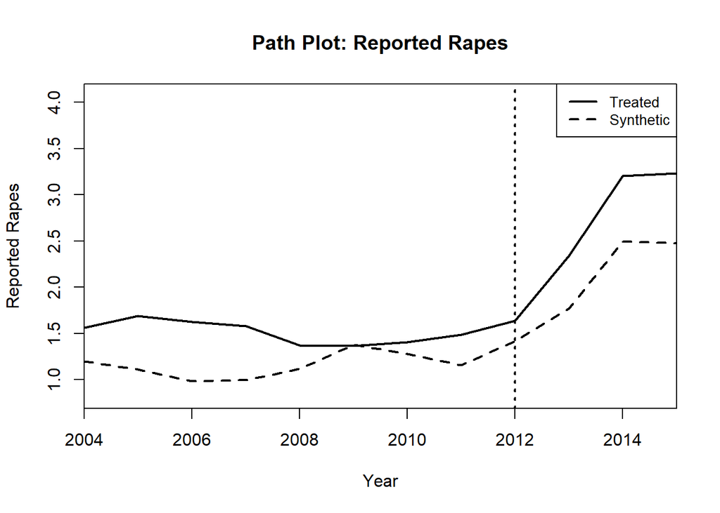

```r
# For Rape cases
plot_path(
  dp = rape_results$dataprep,
  synth_out = rape_results$synth_out,
  ylab = "Reported Rapes",
  title = "Path Plot: Reported Rapes"
)
```

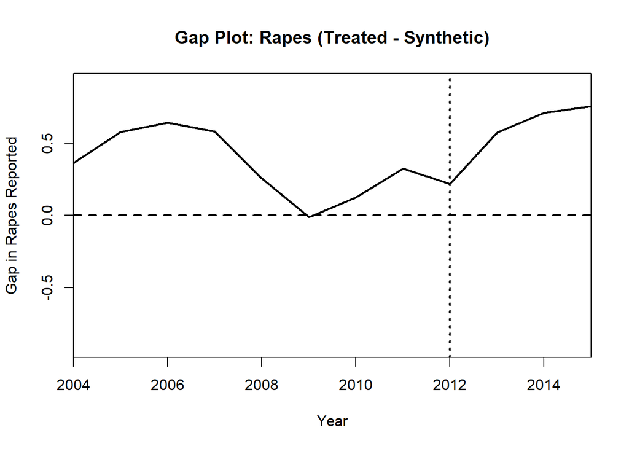

```r
plot_gaps(
  synth.res = rape_results$synth_out,
  dataprep.res = rape_results$dataprep,
  ylab = "Gap in Rapes Reported",
  title = "Gap Plot: Rapes (Treated - Synthetic)"
)
```

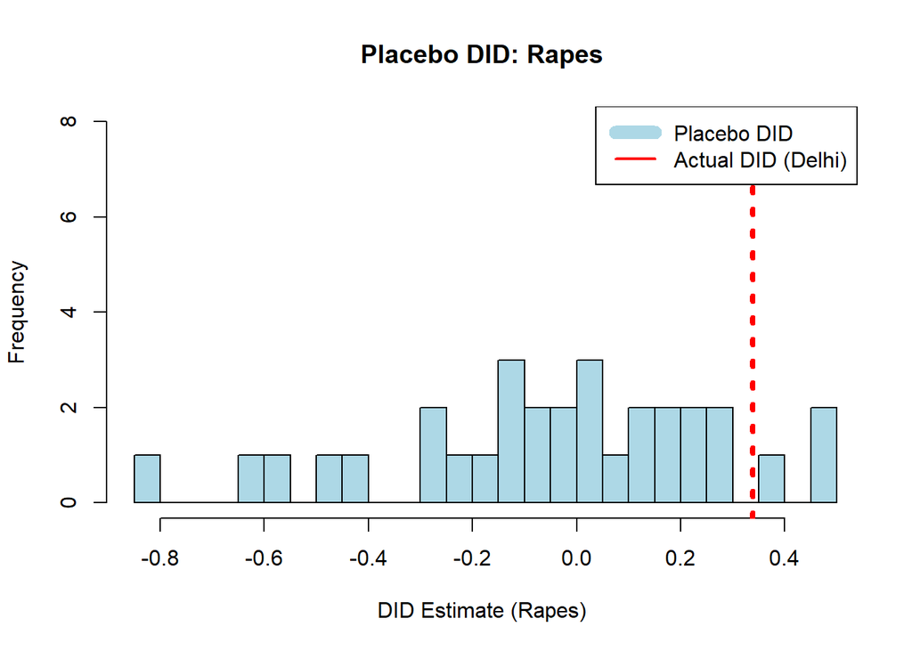

```r
plot_placebo_hist(
  placebo_did = placebo_rape$did,
  did_actual = rape_results$did,
  xlab = "DID Estimate (Rapes)",
  title = "Placebo DID: Rapes"
)
```

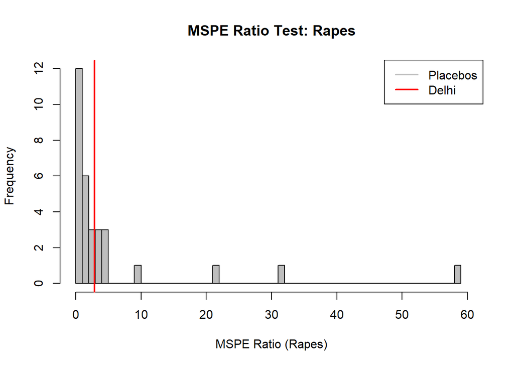

```r
plot_mspe_hist(
  placebo_ratios = placebo_rape$mspe_ratio,
  treated_ratio = mspe_rape,
  xlab = "MSPE Ratio (Rapes)",
  title = "MSPE Ratio Test: Rapes",
  xlim = c(0,60)
)
```

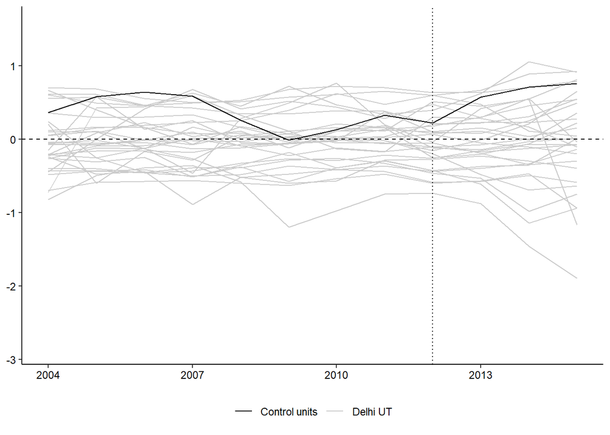

```r
# Plotting Placebos
plot_placebos(rape_results$placebos)
```

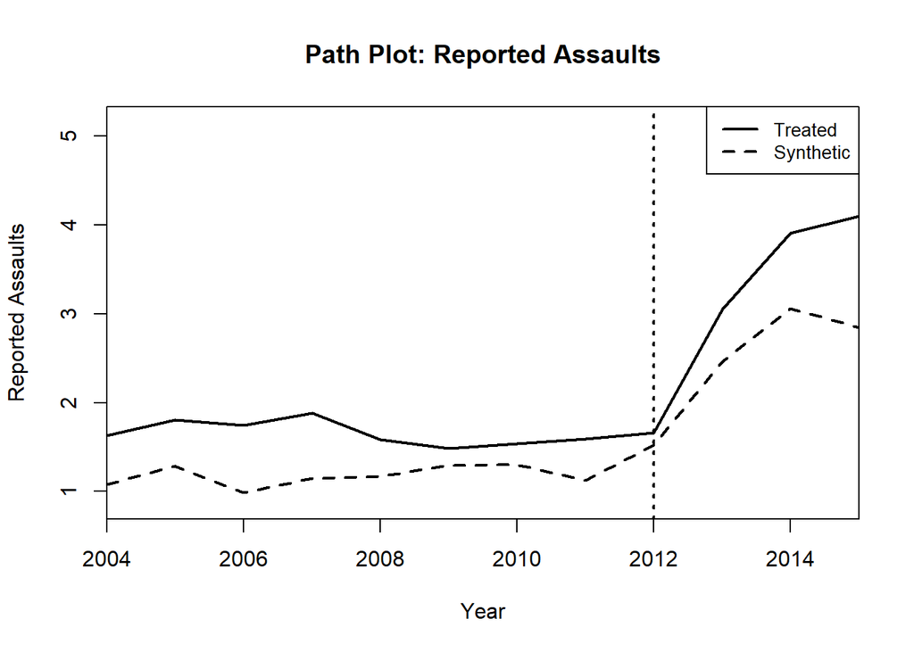

```r
# For Assault Cases
plot_path(
  dp = assault_results$dataprep,
  synth_out = assault_results$synth_out,
  ylab = "Reported Assaults",
  title = "Path Plot: Reported Assaults"
)
```

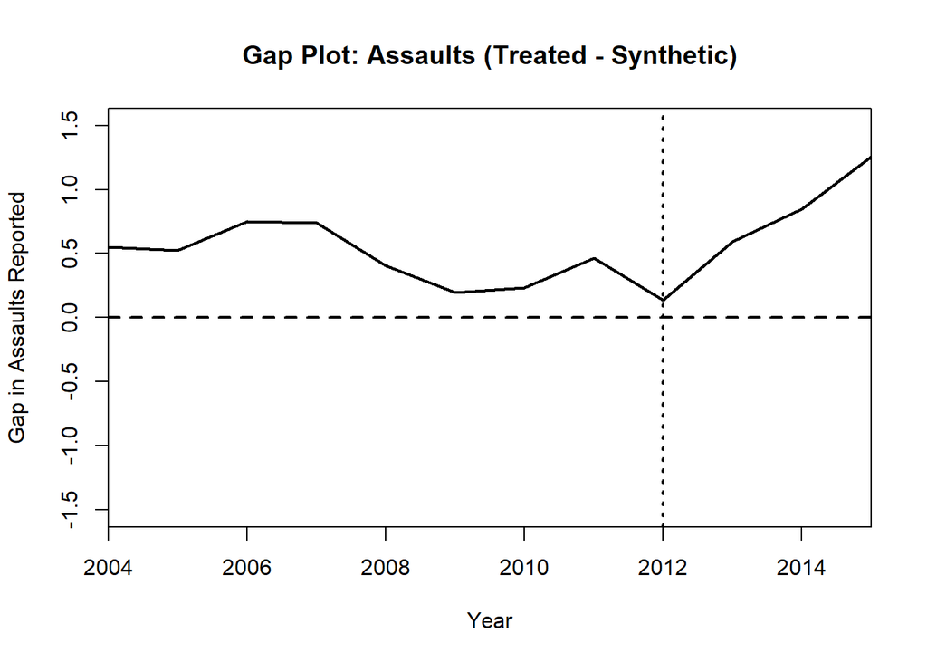

```r
plot_gaps(
  synth.res = assault_results$synth_out,
  dataprep.res = assault_results$dataprep,
  ylab = "Gap in Assaults Reported",
  title = "Gap Plot: Assaults (Treated - Synthetic)"
)
```

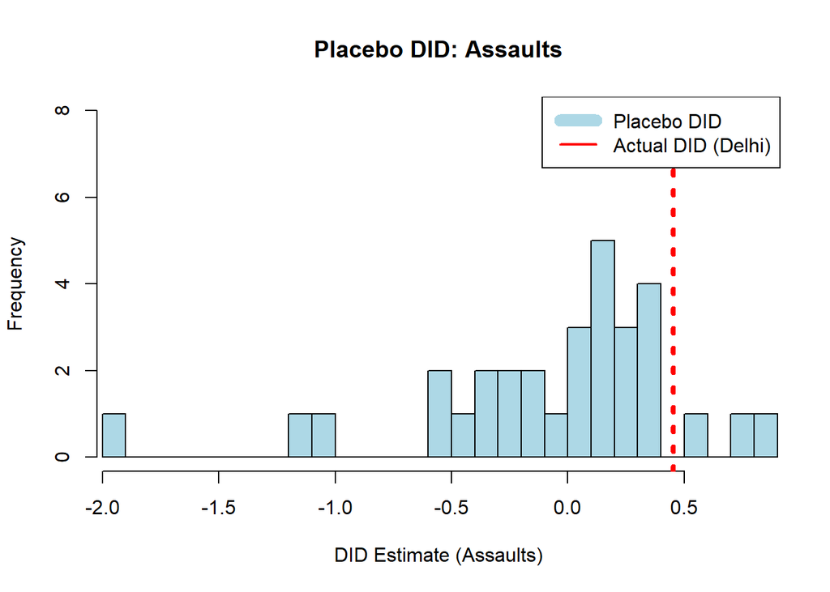

```r
plot_placebo_hist(
  placebo_did = placebo_assault$did,
  did_actual = assault_results$did,
  xlab = "DID Estimate (Assaults)",
  title = "Placebo DID: Assaults"
)
```

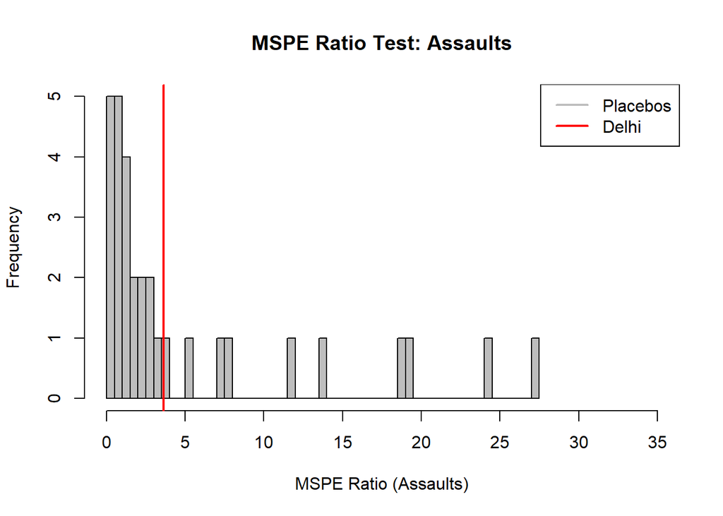

```r
plot_mspe_hist(
  placebo_ratios = placebo_assault$mspe_ratio,
  treated_ratio = mspe_assault,
  xlab = "MSPE Ratio (Assaults)",
  title = "MSPE Ratio Test: Assaults",
  xlim = c(0,35)
)
```

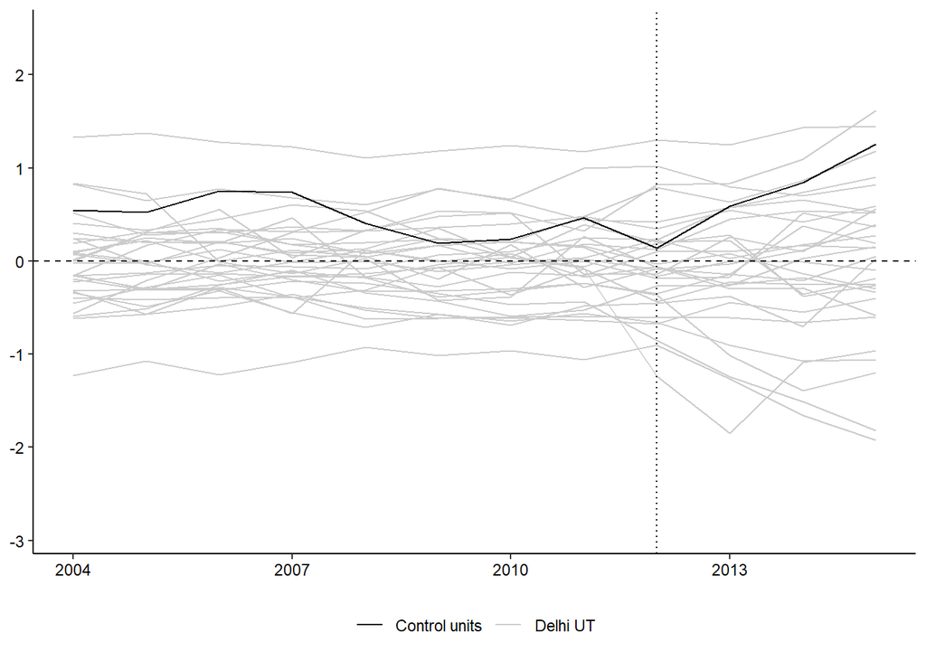

```r
# Plotting Placebos
plot_placebos(assault_results$placebos)
```

##### Analyze Insult Cases

```r
# Run SCM for Insult
insult_results <- run_scm_analysis(
  data = df_mod_modified_synth_filtered,
  outcome_var = "INSULT TO THE MODESTY OF WOMEN",
  return.placebos = TRUE
)
```

[output not shown]

[output cut: 584 more lines]

[output not shown]

```r
# Run Placebo Tests for INSULT (DID + MSPE)
placebo_insult <- run_placebo_tests(
  data = df_mod_modified_synth_filtered,
  outcome_var = "INSULT TO THE MODESTY OF WOMEN"
)
```

[output not shown]

[output cut: 564 more lines]

[output not shown]

```r
# Calculate MSPE Ratio for Delhi (INSULT)
mspe_insult <- calculate_mspe_ratio(
  dp = insult_results$dataprep,
  synth_out = insult_results$synth_out,
  pre_treatment = insult_results$pre_treatment,
  post_treatment = insult_results$post_treatment
)

# Calculate p-values
p_did_insult <- mean(placebo_insult$did >= insult_results$did)
p_mspe_insult <- mean(placebo_insult$mspe_ratio >= mspe_insult)

cat("Insult to Modesty of Women Analysis:\n",
    "DID Estimate:", insult_results$did, "\n",
    "DID p-value:", p_did_insult, "\n",
    "MSPE Ratio:", mspe_insult, "\n",
    "MSPE p-value:", p_mspe_insult)
```

```
## Insult to Modesty of Women Analysis:
##  DID Estimate: 1.087223
##  DID p-value: 0
##  MSPE Ratio: 43.43929
##  MSPE p-value: 0
```

###### Plots

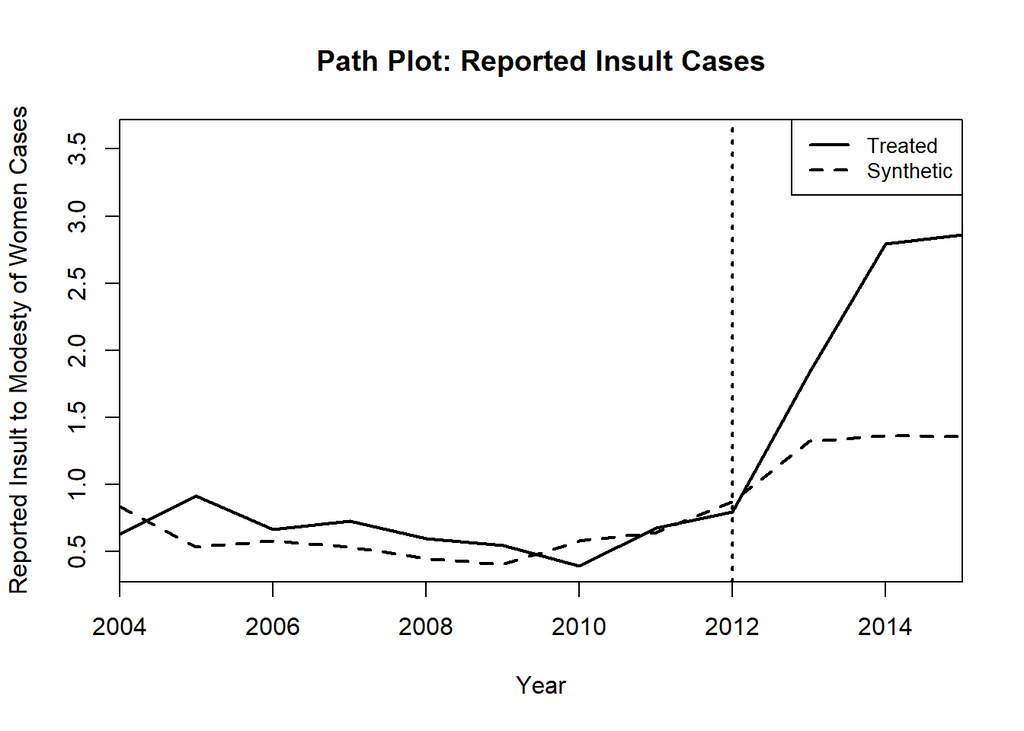

```r
# For Insult to Modesty of Women
plot_path(
  dp = insult_results$dataprep,
  synth_out = insult_results$synth_out,
  ylab = "Reported Insult to Modesty of Women Cases",
  title = "Path Plot: Reported Insult Cases"
)
```

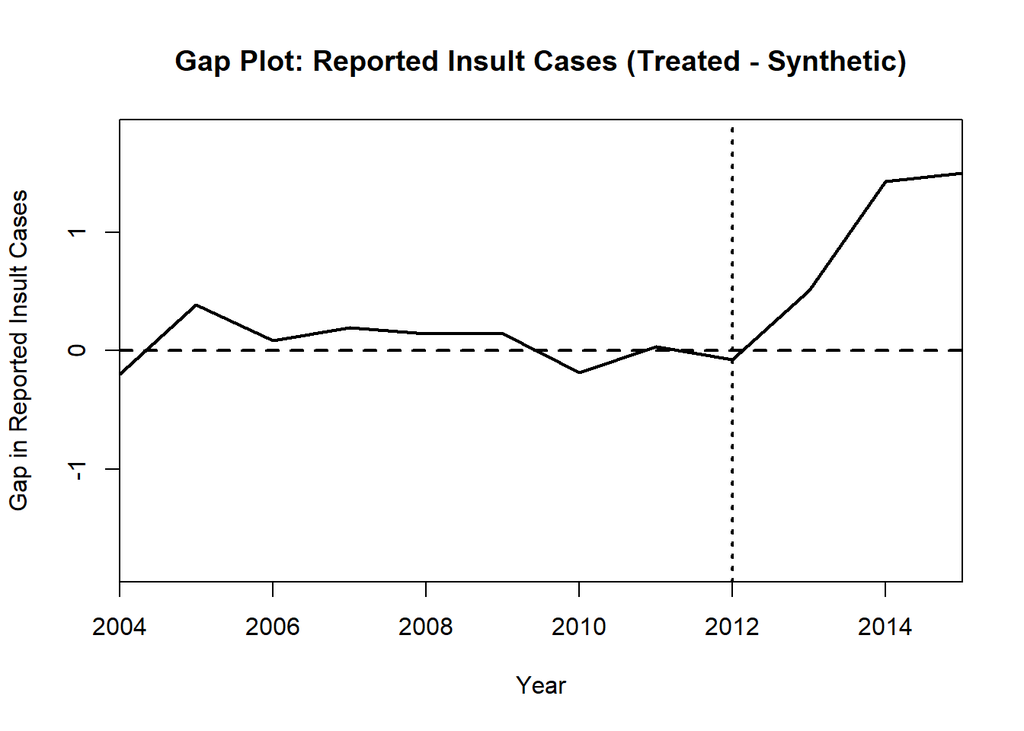

```r
plot_gaps(
  synth.res = insult_results$synth_out,
  dataprep.res = insult_results$dataprep,
  ylab = "Gap in Reported Insult Cases",
  title = "Gap Plot: Reported Insult Cases (Treated - Synthetic)"
)
```

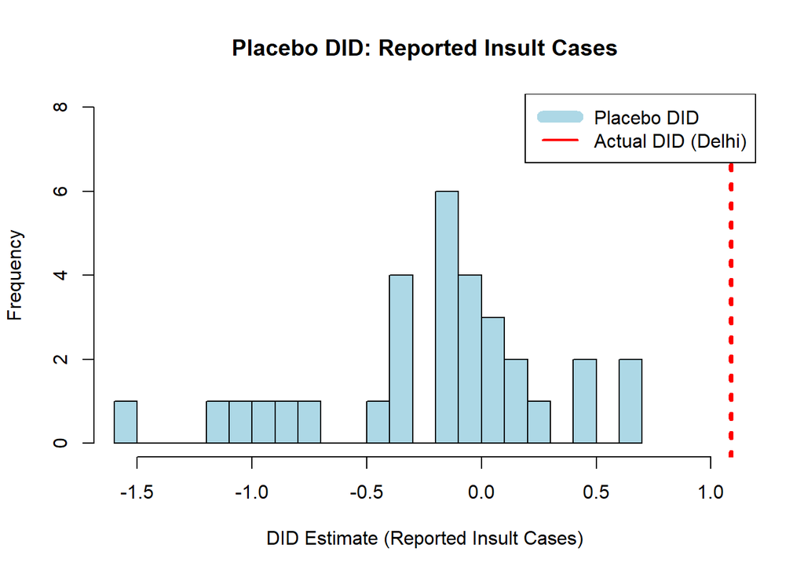

```r
plot_placebo_hist(
  placebo_did = placebo_insult$did,
  did_actual = insult_results$did,
  xlab = "DID Estimate (Reported Insult Cases)",
  title = "Placebo DID: Reported Insult Cases"
)
```

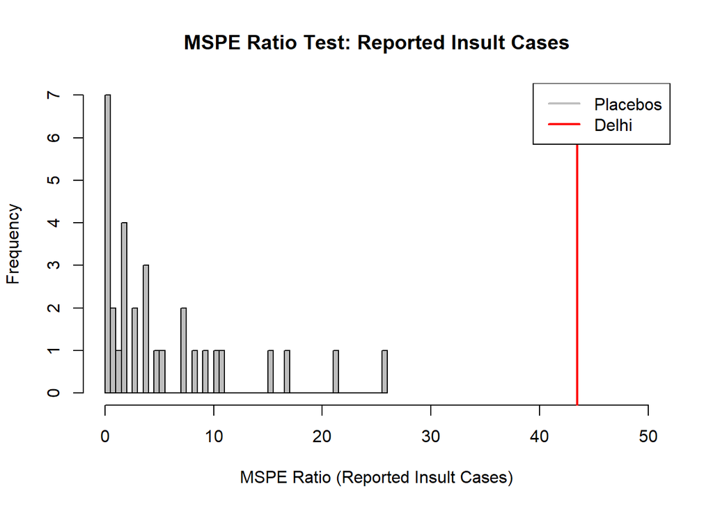

```r
plot_mspe_hist(
  placebo_ratios = placebo_insult$mspe_ratio,
  treated_ratio = mspe_insult,
  xlab = "MSPE Ratio (Reported Insult Cases)",
  title = "MSPE Ratio Test: Reported Insult Cases",
  xlim = c(0,50)
)
```

[figure not shown]

```r
# Plotting Placebos
plot_placebos(insult_results$placebos)
```

### Falsification Tests on Accidents and Murders

##### Analyze Accident Cases

```r
# Run SCM for Total Accidents
accident_results <- run_scm_analysis(
  data = df_mod_modified_synth_filtered,
  outcome_var = "Total Accidents",
  return.placebos = TRUE
)
```

[output not shown]

[output cut: 584 more lines]

[output not shown]

```r
# Run Placebo Tests for Accident (DID + MSPE)
placebo_accident <- run_placebo_tests(
  data = df_mod_modified_synth_filtered,
  outcome_var = "Total Accidents"
)
```

[output not shown]

[output cut: 564 more lines]

[output not shown]

```r
# Calculate MSPE Ratio for Delhi (accident)
mspe_accident <- calculate_mspe_ratio(
  dp = accident_results$dataprep,
  synth_out = accident_results$synth_out,
  pre_treatment = accident_results$pre_treatment,
  post_treatment = accident_results$post_treatment
)

# Calculate p-values
p_did_accident <- mean(placebo_accident$did >= accident_results$did)
p_mspe_accident <- mean(placebo_accident$mspe_ratio >= mspe_accident)

cat("Total Accident Analysis:\n",
    "DID Estimate:", accident_results$did, "\n",
    "DID p-value:", p_did_accident, "\n",
    "MSPE Ratio:", mspe_accident, "\n",
    "MSPE p-value:", p_mspe_accident)
```

```
## Total Accident Analysis:
##  DID Estimate: -0.03012555
##  DID p-value: 0.516129
##  MSPE Ratio: 1.041582
##  MSPE p-value: 0.483871
```

###### Plots

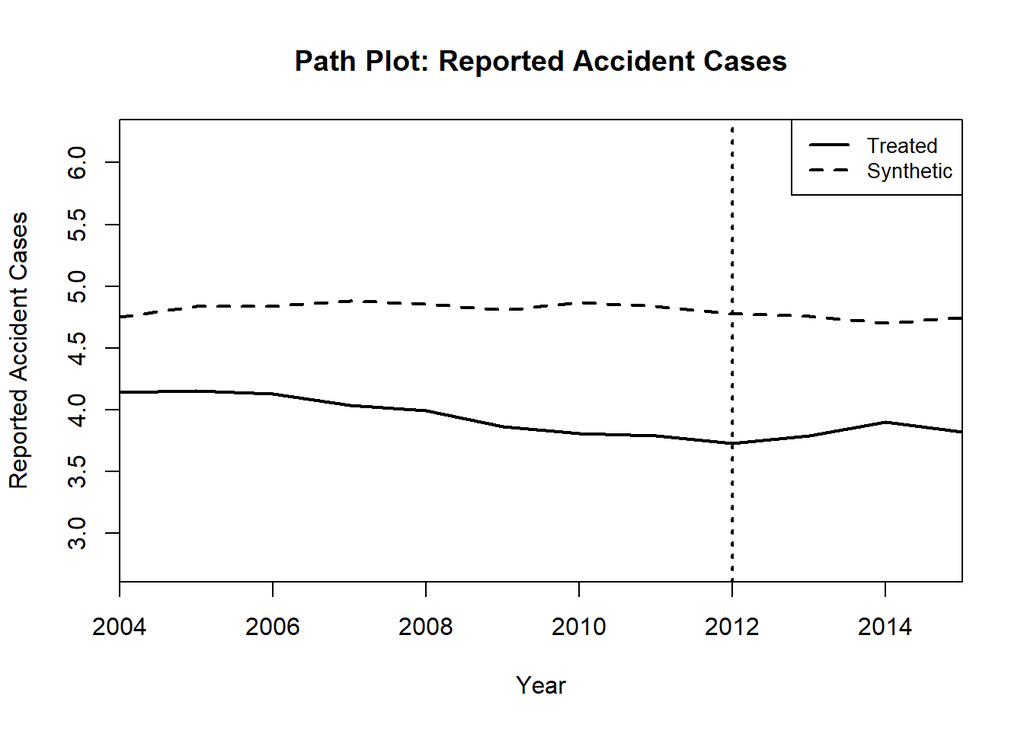

```r
# For Accident Cases
plot_path(
  dp = accident_results$dataprep,
  synth_out = accident_results$synth_out,
  ylab = "Reported Accident Cases",
  title = "Path Plot: Reported Accident Cases"
)
```

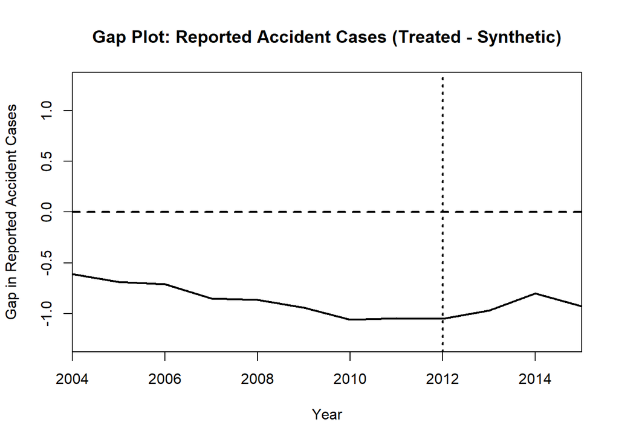

```r
plot_gaps(
  synth.res = accident_results$synth_out,
  dataprep.res = accident_results$dataprep,
  ylab = "Gap in Reported Accident Cases",
  title = "Gap Plot: Reported Accident Cases (Treated - Synthetic)"
)
```

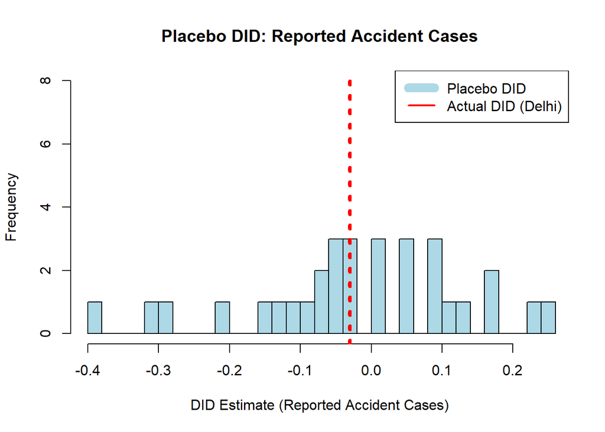

```r
plot_placebo_hist(
  placebo_did = placebo_accident$did,
  did_actual = accident_results$did,
  xlab = "DID Estimate (Reported Accident Cases)",
  title = "Placebo DID: Reported Accident Cases"
)
```

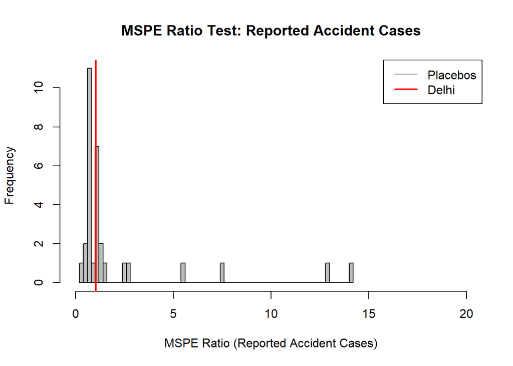

```r
plot_mspe_hist(
  placebo_ratios = placebo_accident$mspe_ratio,
  treated_ratio = mspe_accident,
  xlab = "MSPE Ratio (Reported Accident Cases)",
  title = "MSPE Ratio Test: Reported Accident Cases",
  xlim = c(0,20)
)
```

[figure not shown]

```r
# Plotting Placebos
plot_placebos(accident_results$placebos)
```

##### Analyze Murder Cases

```r
# Run SCM for MURDERS per 100k
murder_results <- run_scm_analysis(
  data = df_mod_modified_synth_filtered,
  outcome_var = "MURDERS per 100k",
  return.placebos = TRUE
)
```

[output not shown]

[output cut: 584 more lines]

[output not shown]

```r
# Run Placebo Tests for MURDERS per 100k (DID + MSPE)
placebo_murder <- run_placebo_tests(
  data = df_mod_modified_synth_filtered,
  outcome_var = "MURDERS per 100k"
)
```

[output not shown]

[output cut: 564 more lines]

[output not shown]

```r
# Calculate MSPE Ratio for Delhi (murder)
mspe_murder <- calculate_mspe_ratio(
  dp = murder_results$dataprep,
  synth_out = murder_results$synth_out,
  pre_treatment = murder_results$pre_treatment,
  post_treatment = murder_results$post_treatment
)

# Calculate p-values
p_did_murder <- mean(placebo_murder$did >= murder_results$did)
p_mspe_murder <- mean(placebo_murder$mspe_ratio >= mspe_murder)

cat("Murder Analysis:\n",
    "DID Estimate:", murder_results$did, "\n",
    "DID p-value:", p_did_murder, "\n",
    "MSPE Ratio:", mspe_murder, "\n",
    "MSPE p-value:", p_mspe_murder)
```

```
## Murder Analysis:
##  DID Estimate: 0.1671146
##  DID p-value: 0.09677419
##  MSPE Ratio: 4.277187
##  MSPE p-value: 0.03225806
```

###### Plots

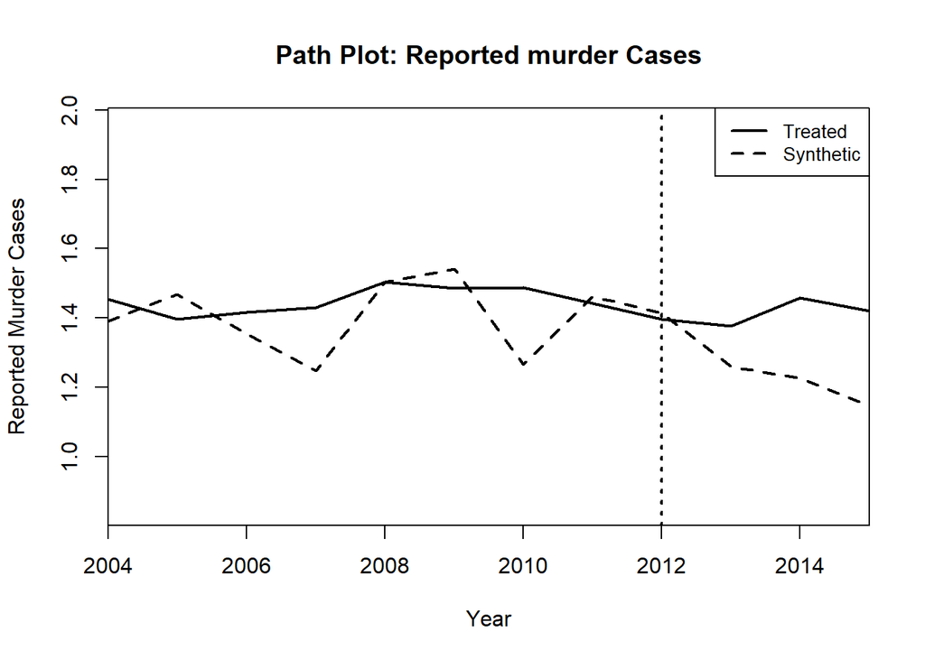

```r
# For Murder Cases
plot_path(
  dp = murder_results$dataprep,
  synth_out = murder_results$synth_out,
  ylab = "Reported Murder Cases",
  title = "Path Plot: Reported murder Cases"
)
```

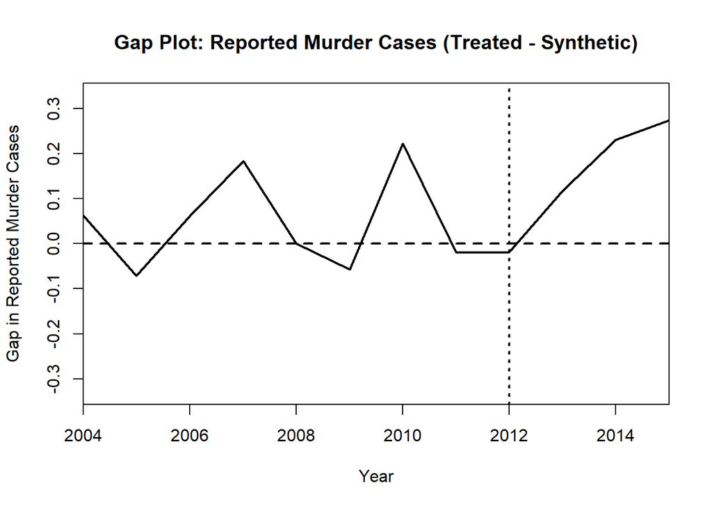

```r
plot_gaps(
  synth.res = murder_results$synth_out,
  dataprep.res = murder_results$dataprep,
  ylab = "Gap in Reported Murder Cases",
  title = "Gap Plot: Reported Murder Cases (Treated - Synthetic)"
)
```

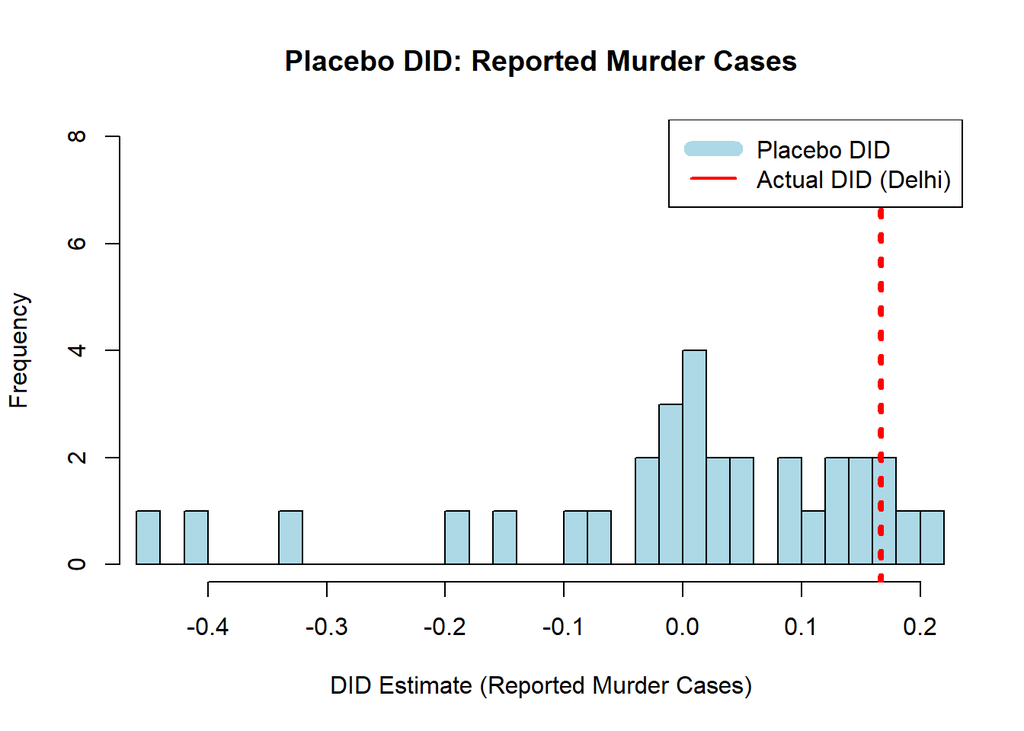

```r
plot_placebo_hist(
  placebo_did = placebo_murder$did,
  did_actual = murder_results$did,
  xlab = "DID Estimate (Reported Murder Cases)",
  title = "Placebo DID: Reported Murder Cases"
)
```

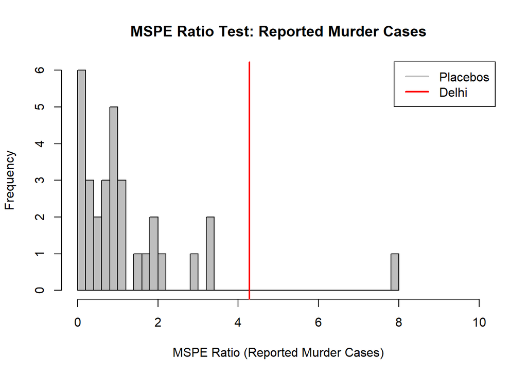

```r
plot_mspe_hist(
  placebo_ratios = placebo_murder$mspe_ratio,
  treated_ratio = mspe_murder,
  xlab = "MSPE Ratio (Reported Murder Cases)",
  title = "MSPE Ratio Test: Reported Murder Cases",
  xlim = c(0,10)
)
```

[figure not shown]

```r
# Plotting Placebos
plot_placebos(murder_results$placebos)
```

#### XXXX End of Analysis. XXXX

## XXXX Fake time Treatment Check XXXX

For Fake Treatment in year 2008, so pretreatment time period is 2004-2008, and post treatment period is 2009-2012. #### Function to Run SCM Analysis

```r
run_scm_analysis_f <- function(
    data,
    outcome_var,
    treatment_id = 10,
    predictors = c("Literacy Growth Rate",
                   "Per Capita Income_Current",
                   "Per Capita Income_Constant"),
    pre_years = 2004:2008,
    post_years = 2009:2012,
    unit_var = "StateID",
    time_var = "Year",
    unit_names_var = "State"
) {

  # Data preparation
  dp <- dataprep(
    foo = data,
    predictors = predictors,
    dependent = outcome_var,
    unit.variable = unit_var,
    time.variable = time_var,
    treatment.identifier = treatment_id,
    controls.identifier = setdiff(unique(data[[unit_var]]), treatment_id),
    time.predictors.prior = pre_years,
    time.optimize.ssr = pre_years,
    unit.names.variable = unit_names_var,
    time.plot = c(pre_years, post_years)
  )

  # Run Synth
  synth_out <- synth(dp)

  # Calculate gaps and DID
  gaps <- dp$Y1plot - (dp$Y0plot %*% synth_out$solution.w)
  time_indices <- dp$tag$time.plot
  pre_treatment <- time_indices %in% pre_years
  post_treatment <- time_indices %in% post_years
  did <- mean(gaps[post_treatment]) - mean(gaps[pre_treatment])

  # Return results
  list(
    dataprep = dp,
    synth_out = synth_out,
    gaps = gaps,
    did = did,
    pre_treatment = pre_treatment,
    post_treatment = post_treatment
  )
}
```

#### Function to Run Placebo Tests (DID + MSPE)

```r
run_placebo_tests_f <- function(
    data,
    outcome_var,
    treatment_id = 10,
    predictors = c("Literacy Growth Rate",
                   "Per Capita Income_Current",
                   "Per Capita Income_Constant"),
    pre_years = 2004:2008,
    post_years = 2009:2012,
    unit_var = "StateID",
    unit_names_var = "State"
) {

  controls <- setdiff(unique(data[[unit_var]]), treatment_id)
  placebo_results <- data.frame(
    state_id = controls,
    did = numeric(length(controls)),
    mspe_ratio = numeric(length(controls))
  )

  for (i in seq_along(controls)) {
    state_id <- controls[i]

    # Prepare data for placebo unit
    dp_placebo <- dataprep(
      foo = data,
      predictors = predictors,
      dependent = outcome_var,
      unit.variable = unit_var,
      time.variable = "Year",
      treatment.identifier = state_id,
      controls.identifier = setdiff(unique(data[[unit_var]]), state_id),
      time.predictors.prior = pre_years,
      time.optimize.ssr = pre_years,
      unit.names.variable = unit_names_var,
      time.plot = c(pre_years, post_years)
    )

    # Run Synth
    synth_placebo <- synth(dp_placebo)

    # Calculate gaps and DID
    gaps_placebo <- dp_placebo$Y1plot - (dp_placebo$Y0plot %*% synth_placebo$solution.w)
    time_indices <- dp_placebo$tag$time.plot
    pre <- time_indices %in% pre_years
    post <- time_indices %in% post_years
    did_placebo <- mean(gaps_placebo[post]) - mean(gaps_placebo[pre])

    # Calculate MSPE ratio
    pre_actual <- dp_placebo$Y1plot[pre]
    pre_synth <- dp_placebo$Y0plot[pre, ] %*% synth_placebo$solution.w
    pre_mspe <- mean((pre_actual - pre_synth)^2)

    post_actual <- dp_placebo$Y1plot[post]
    post_synth <- dp_placebo$Y0plot[post, ] %*% synth_placebo$solution.w
    post_mspe <- mean((post_actual - post_synth)^2)
    mspe_ratio <- post_mspe / pre_mspe

    # Store results
    placebo_results$did[i] <- did_placebo
    placebo_results$mspe_ratio[i] <- mspe_ratio
  }

  placebo_results
}
```

#### Estimates for Rapes

```r
# Run SCM for Rape
f_rape_results <- run_scm_analysis_f(
  data = df_mod_modified_synth_filtered,
  outcome_var = "RAPE"
)
```

```
##
## X1, X0, Z1, Z0 all come directly from dataprep object.
##
##
## ****************
##  searching for synthetic control unit
##
##
## ****************
## ****************
## ****************
##
## MSPE (LOSS V): 0.1636636
##
## solution.v:
##  0.3762901 0.3455854 0.2781245
##
## solution.w:
##  0.004777395 0.001199361 0.00105704 0.001423133 0.0008192207 0.8964255 0.001357501 0.0003454373 0.001825367 0.001566974 0.003245603 0.001146373 0.001063944 0.001616946 0.03950452 0.001360515 0.002953109 0.001939014 0.001453691 0.01007822 0.001948998 0.001415873 0.005857723 0.00168378 0.001191245 …
```

```r
# Run Placebo Tests for Rape (DID + MSPE)
f_placebo_rape <- run_placebo_tests_f(
  data = df_mod_modified_synth_filtered,
  outcome_var = "RAPE"
)
```

[output not shown]

[output cut: 564 more lines]

[output not shown]

```r
# Calculate MSPE Ratio for Delhi (Rape)
f_mspe_rape <- calculate_mspe_ratio(
  dp = f_rape_results$dataprep,
  synth_out = f_rape_results$synth_out,
  pre_treatment = f_rape_results$pre_treatment,
  post_treatment = f_rape_results$post_treatment
)

# Calculate p-values
f_p_did_rape <- mean(f_placebo_rape$did >= f_rape_results$did)
f_p_mspe_rape <- mean(f_placebo_rape$mspe_ratio >= f_mspe_rape)

cat("Rape Analysis:\n",
    "DID Estimate:", f_rape_results$did, "\n",
    "DID p-value:", f_p_did_rape, "\n",
    "MSPE Ratio:", f_mspe_rape, "\n",
    "MSPE p-value:", f_p_mspe_rape)
```

```
## Rape Analysis:
##  DID Estimate: -0.2268326
##  DID p-value: 0.9354839
##  MSPE Ratio: 0.2708596
##  MSPE p-value: 0.9677419
```

##### Plots for Reported Rapes

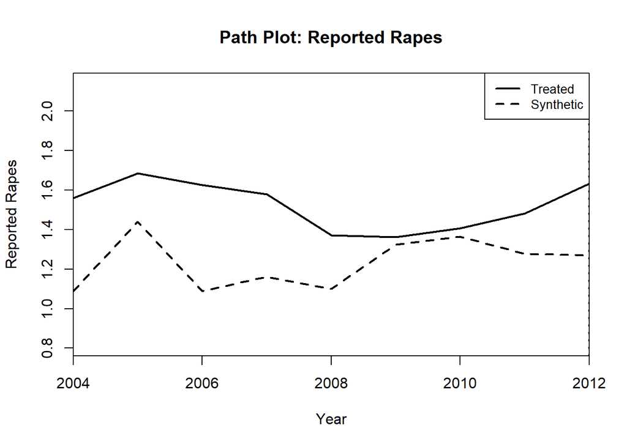

```r
# For Rape cases
plot_path(
  dp = f_rape_results$dataprep,
  synth_out = f_rape_results$synth_out,
  ylab = "Reported Rapes",
  title = "Path Plot: Reported Rapes"
)
```

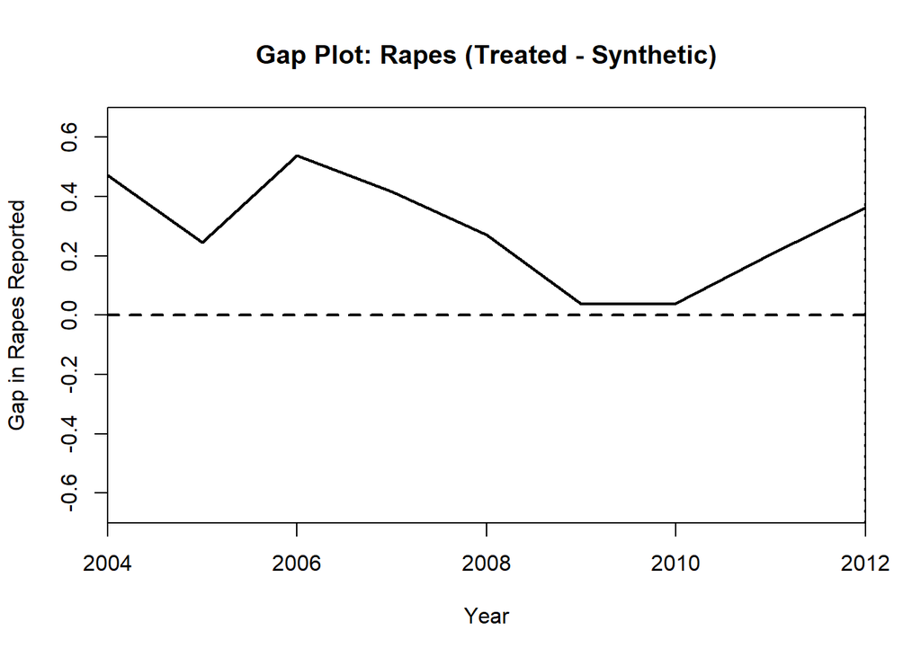

```r
plot_gaps(
  synth.res = f_rape_results$synth_out,
  dataprep.res = f_rape_results$dataprep,
  ylab = "Gap in Rapes Reported",
  title = "Gap Plot: Rapes (Treated - Synthetic)"
)
```

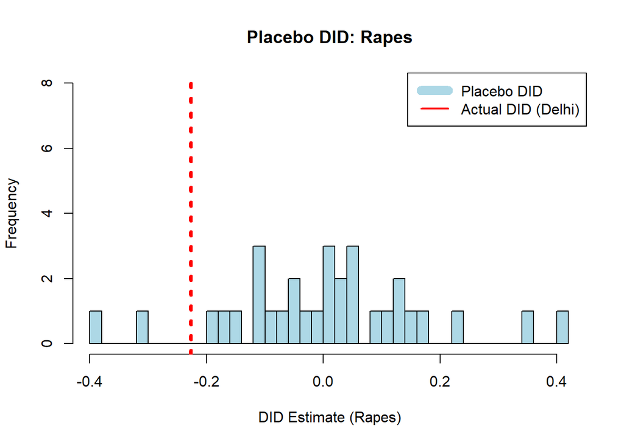

```r
plot_placebo_hist(
  placebo_did = f_placebo_rape$did,
  did_actual = f_rape_results$did,
  xlab = "DID Estimate (Rapes)",
  title = "Placebo DID: Rapes"
)
```

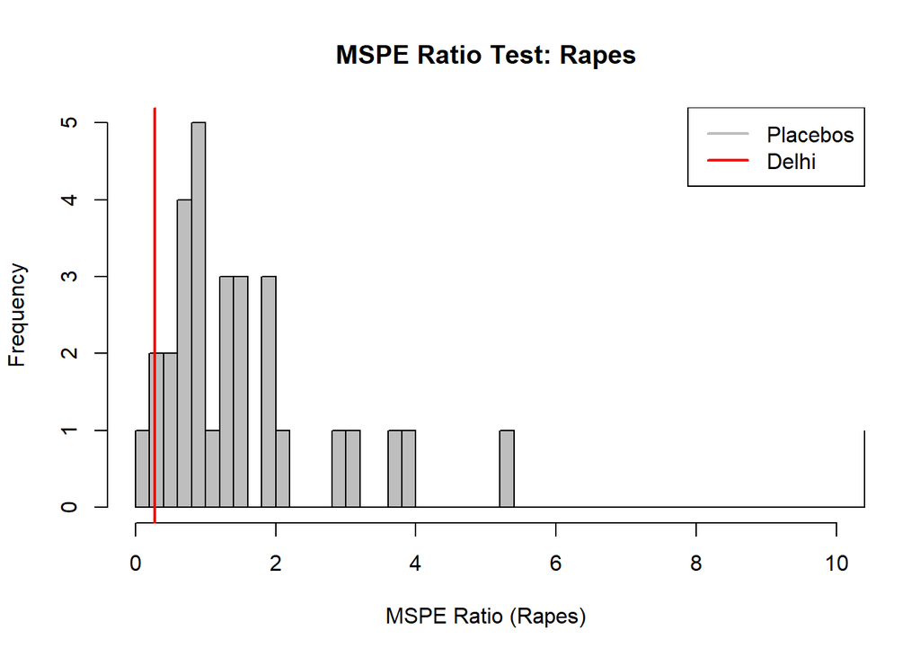

```r
plot_mspe_hist(
  placebo_ratios = f_placebo_rape$mspe_ratio,
  treated_ratio = f_mspe_rape,
  xlab = "MSPE Ratio (Rapes)",
  title = "MSPE Ratio Test: Rapes",
  xlim = c(0,10)
)
```

#### Estimates for Molestation & Assault Cases

```r
# Run SCM for Assault
f_assault_results <- run_scm_analysis_f(
  data = df_mod_modified_synth_filtered,
  outcome_var = "ASSAULT ON WOMEN WITH INTENT TO OUTRAGE HER MODESTY"
)
```

```
##
## X1, X0, Z1, Z0 all come directly from dataprep object.
##
##
## ****************
##  searching for synthetic control unit
##
##
## ****************
## ****************
## ****************
##
## MSPE (LOSS V): 0.1921035
##
## solution.v:
##  0.4286851 0.3508813 0.2204336
##
## solution.w:
##  0.004345655 0.001251541 0.001109965 0.001436013 0.0008505313 0.8949595 0.001386958 0.0003667883 0.001840209 0.001629479 0.003043321 0.0011833 0.00109983 0.001641913 0.04287026 0.001376651 0.002799746 0.001903405 0.001479433 0.009606538 0.00192786 0.001435977 0.005078658 0.001716167 0.00122653 0.…
```

```r
# Run Placebo Tests for Assault (DID + MSPE)
f_placebo_assault <- run_placebo_tests_f(
  data = df_mod_modified_synth_filtered,
  outcome_var = "ASSAULT ON WOMEN WITH INTENT TO OUTRAGE HER MODESTY"
)
```

[output not shown]

[output cut: 564 more lines]

[output not shown]

```r
# Calculate MSPE Ratio for Delhi (Assault)
f_mspe_assault <- calculate_mspe_ratio(
  dp = f_assault_results$dataprep,
  synth_out = f_assault_results$synth_out,
  pre_treatment = f_assault_results$pre_treatment,
  post_treatment = f_assault_results$post_treatment
)

# Calculate p-values
f_p_did_assault <- mean(f_placebo_assault$did >= f_assault_results$did)
f_p_mspe_assault <- mean(f_placebo_assault$mspe_ratio >= f_mspe_assault)

cat("Assault Analysis:\n",
    "DID Estimate:", f_assault_results$did, "\n",
    "DID p-value:", f_p_did_assault, "\n",
    "MSPE Ratio:", f_mspe_assault, "\n",
    "MSPE p-value:", f_p_mspe_assault)
```

```
## Assault Analysis:
##  DID Estimate: -0.2550954
##  DID p-value: 0.9032258
##  MSPE Ratio: 0.284365
##  MSPE p-value: 0.9354839
```

##### Plots for Assault

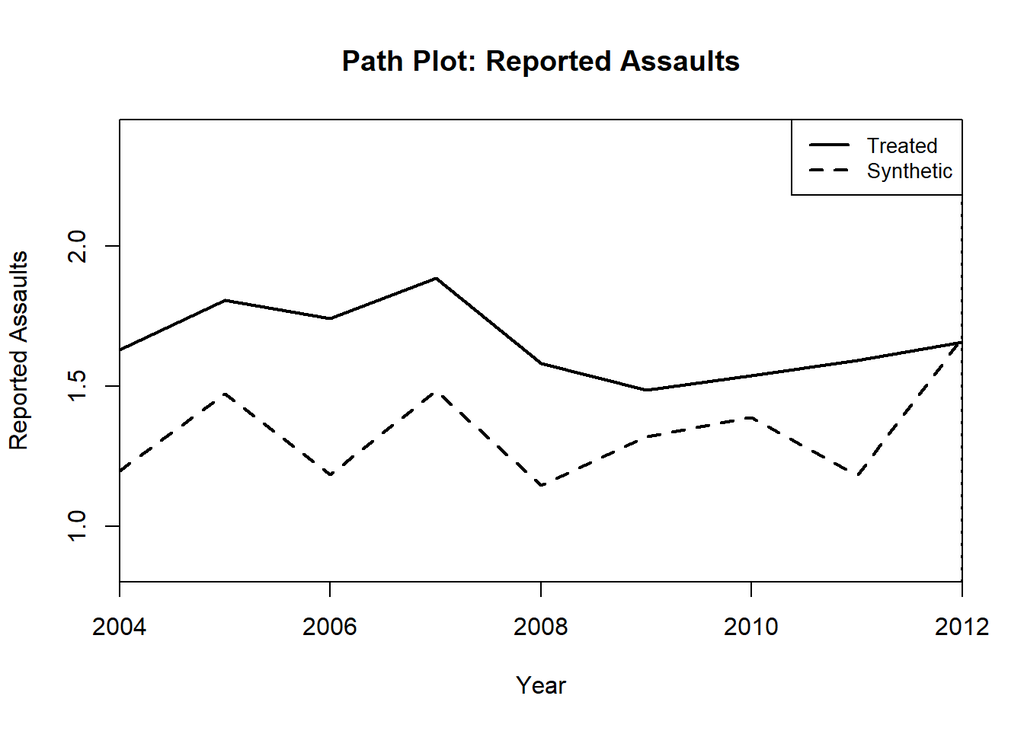

```r
# For Assault Cases
plot_path(
  dp = f_assault_results$dataprep,
  synth_out = f_assault_results$synth_out,
  ylab = "Reported Assaults",
  title = "Path Plot: Reported Assaults"
)
```

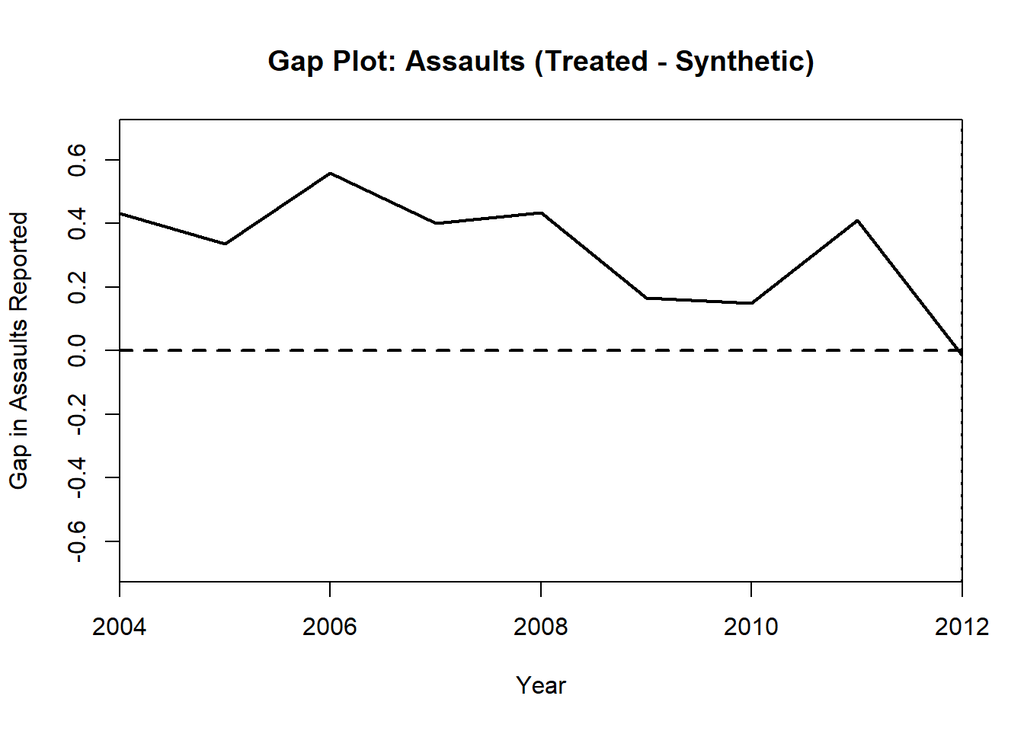

```r
plot_gaps(
  synth.res = f_assault_results$synth_out,
  dataprep.res = f_assault_results$dataprep,
  ylab = "Gap in Assaults Reported",
  title = "Gap Plot: Assaults (Treated - Synthetic)"
)
```

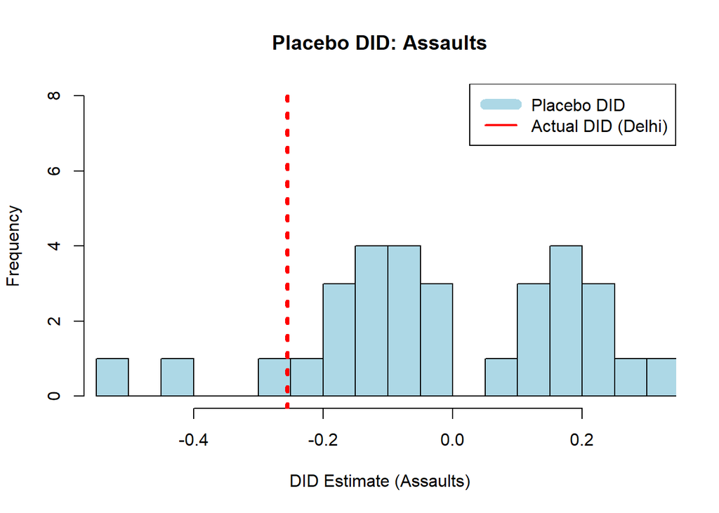

```r
plot_placebo_hist(
  placebo_did = f_placebo_assault$did,
  did_actual = f_assault_results$did,
  xlab = "DID Estimate (Assaults)",
  title = "Placebo DID: Assaults"
)
```

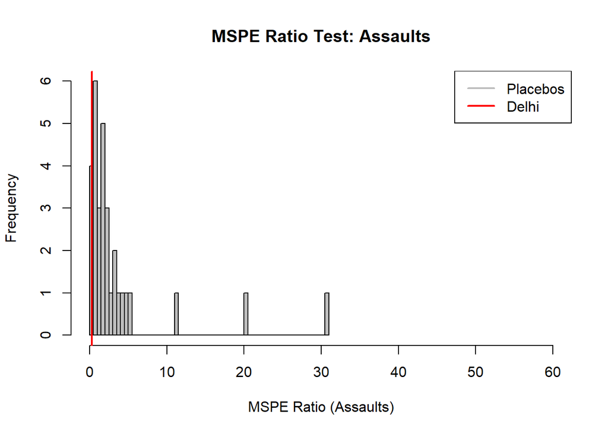

```r
plot_mspe_hist(
  placebo_ratios = f_placebo_assault$mspe_ratio,
  treated_ratio = f_mspe_assault,
  xlab = "MSPE Ratio (Assaults)",
  title = "MSPE Ratio Test: Assaults",
  xlim = c(0,60)
)
```

#### Estimates for Insult (As Insult came out to be highlight significant)

```r
# Run SCM for Insult
f_insult_results <- run_scm_analysis_f(
  data = df_mod_modified_synth_filtered,
  outcome_var = "INSULT TO THE MODESTY OF WOMEN"
)
```

```
##
## X1, X0, Z1, Z0 all come directly from dataprep object.
##
##
## ****************
##  searching for synthetic control unit
##
##
## ****************
## ****************
## ****************
##
## MSPE (LOSS V): 0.05063997
##
## solution.v:
##  0.4877214 0.3926473 0.1196313
##
## solution.w:
##  0.006343831 0.002195127 0.001935532 0.002575961 0.001541849 0.4533977 0.002454381 0.4223081 0.003287231 0.002846234 0.005164573 0.002123647 0.001961551 0.002925519 0.02532447 0.002474098 0.004835871 0.003365194 0.002638504 0.01020156 0.003536393 0.002561054 0.007156111 0.003022097 0.002183287 0.…
```

```r
# Run Placebo Tests for INSULT (DID + MSPE)
f_placebo_insult <- run_placebo_tests_f(
  data = df_mod_modified_synth_filtered,
  outcome_var = "INSULT TO THE MODESTY OF WOMEN"
)
```

[output not shown]

[output cut: 564 more lines]

[output not shown]

```r
# Calculate MSPE Ratio for Delhi (INSULT)
f_mspe_insult <- calculate_mspe_ratio(
  dp = f_insult_results$dataprep,
  synth_out = f_insult_results$synth_out,
  pre_treatment = f_insult_results$pre_treatment,
  post_treatment = f_insult_results$post_treatment
)

# Calculate p-values
f_p_did_insult <- mean(f_placebo_insult$did >= f_insult_results$did)
f_p_mspe_insult <- mean(f_placebo_insult$mspe_ratio >= f_mspe_insult)

cat("Insult to Modesty of Women Analysis:\n",
    "DID Estimate:", f_insult_results$did, "\n",
    "DID p-value:", f_p_did_insult, "\n",
    "MSPE Ratio:", f_mspe_insult, "\n",
    "MSPE p-value:", f_p_mspe_insult)
```

```
## Insult to Modesty of Women Analysis:
##  DID Estimate: -0.1312564
##  DID p-value: 0.8387097
##  MSPE Ratio: 0.3214963
##  MSPE p-value: 0.9032258
```

##### Plots for Insult

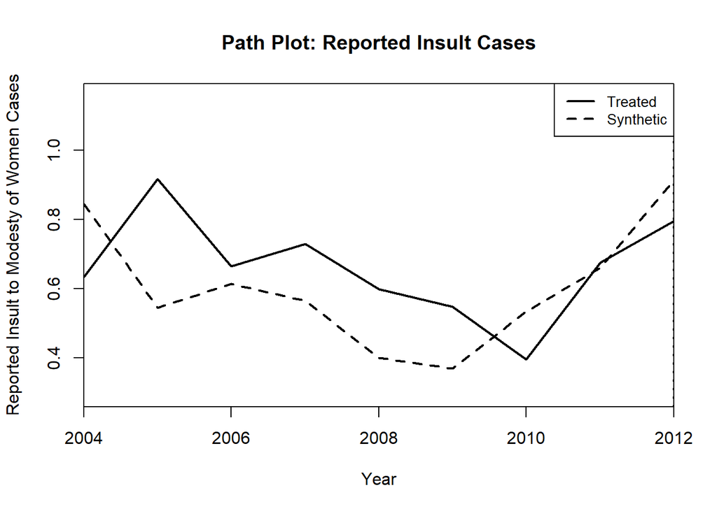

```r
# For Insult to Modesty of Women
plot_path(
  dp = f_insult_results$dataprep,
  synth_out = f_insult_results$synth_out,
  ylab = "Reported Insult to Modesty of Women Cases",
  title = "Path Plot: Reported Insult Cases"
)
```

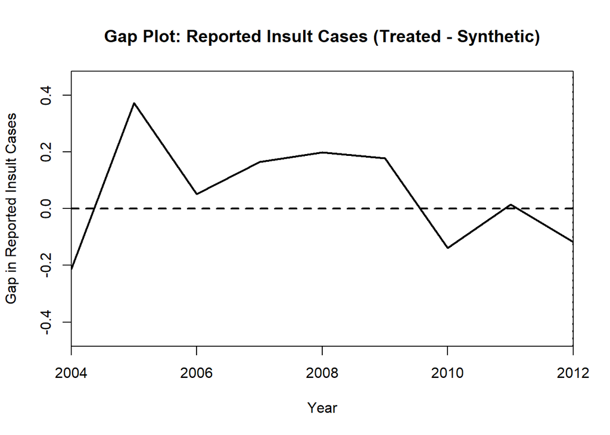

```r
plot_gaps(
  synth.res = f_insult_results$synth_out,
  dataprep.res = f_insult_results$dataprep,
  ylab = "Gap in Reported Insult Cases",
  title = "Gap Plot: Reported Insult Cases (Treated - Synthetic)"
)
```

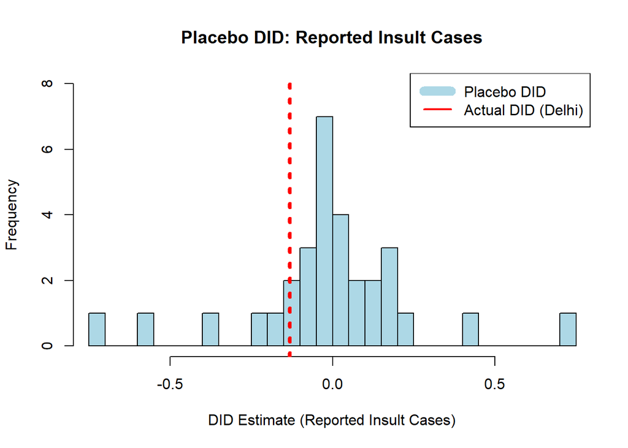

```r
plot_placebo_hist(
  placebo_did = f_placebo_insult$did,
  did_actual = f_insult_results$did,
  xlab = "DID Estimate (Reported Insult Cases)",
  title = "Placebo DID: Reported Insult Cases"
)
```

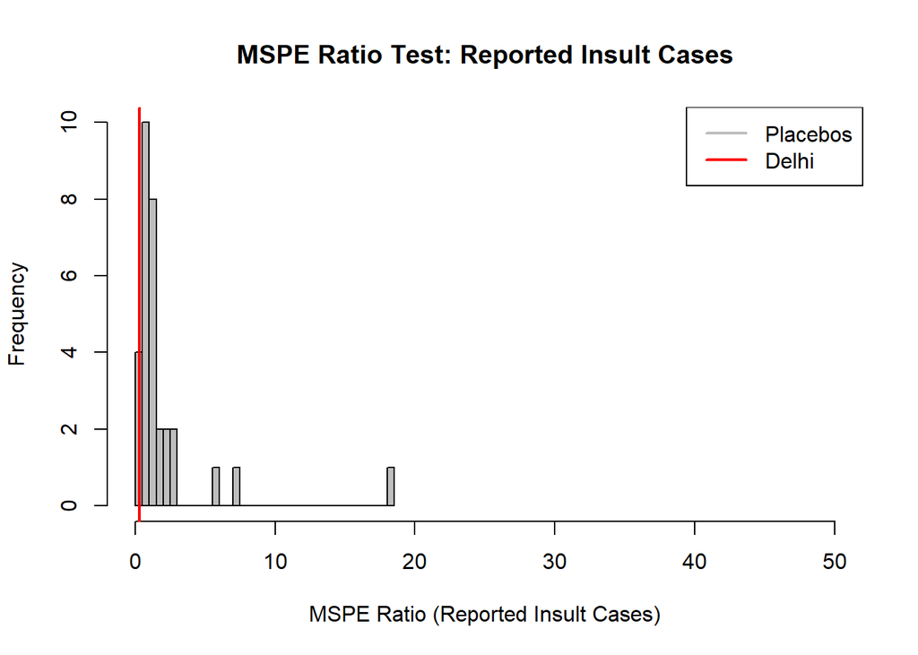

```r
plot_mspe_hist(
  placebo_ratios = f_placebo_insult$mspe_ratio,
  treated_ratio = f_mspe_insult,
  xlab = "MSPE Ratio (Reported Insult Cases)",
  title = "MSPE Ratio Test: Reported Insult Cases",
  xlim = c(0,50)
)
```

#### Estimates for Accidents (as Falsification Test)

```r
# Run SCM for Total Accidents
f_accident_results <- run_scm_analysis_f(
  data = df_mod_modified_synth_filtered,
  outcome_var = "Total Accidents"
)
```

```
##
## X1, X0, Z1, Z0 all come directly from dataprep object.
##
##
## ****************
##  searching for synthetic control unit
##
##
## ****************
## ****************
## ****************
##
## MSPE (LOSS V): 0.008538954
##
## solution.v:
##  0.4195618 0.3248195 0.2556187
##
## solution.w:
##  0.005147603 0.001384864 0.001211957 0.001665827 0.0009702623 0.803169 0.001591357 0.09085309 0.002106512 0.001803844 0.003625433 0.001325375 0.00123941 0.001875457 0.03509383 0.001593524 0.003322874 0.002245155 0.001693502 0.01022548 0.002234278 0.001657115 0.006033615 0.001953161 0.001390027 0.…
```

```r
# Run Placebo Tests for Accident (DID + MSPE)
f_placebo_accident <- run_placebo_tests_f(
  data = df_mod_modified_synth_filtered,
  outcome_var = "Total Accidents"
)
```

[output not shown]

[output cut: 564 more lines]

[output not shown]

```r
# Calculate MSPE Ratio for Delhi (accident)
f_mspe_accident <- calculate_mspe_ratio(
  dp = f_accident_results$dataprep,
  synth_out = f_accident_results$synth_out,
  pre_treatment = f_accident_results$pre_treatment,
  post_treatment = f_accident_results$post_treatment
)

# Calculate p-values
f_p_did_accident <- mean(f_placebo_accident$did >= f_accident_results$did)
f_p_mspe_accident <- mean(f_placebo_accident$mspe_ratio >= f_mspe_accident)

cat("Total Accident Analysis:\n",
    "DID Estimate:", f_accident_results$did, "\n",
    "DID p-value:", f_p_did_accident, "\n",
    "MSPE Ratio:", f_mspe_accident, "\n",
    "MSPE p-value:", f_p_mspe_accident)
```

```
## Total Accident Analysis:
##  DID Estimate: -0.1397482
##  DID p-value: 0.7419355
##  MSPE Ratio: 2.495446
##  MSPE p-value: 0.2258065
```

##### Plots for Accidents

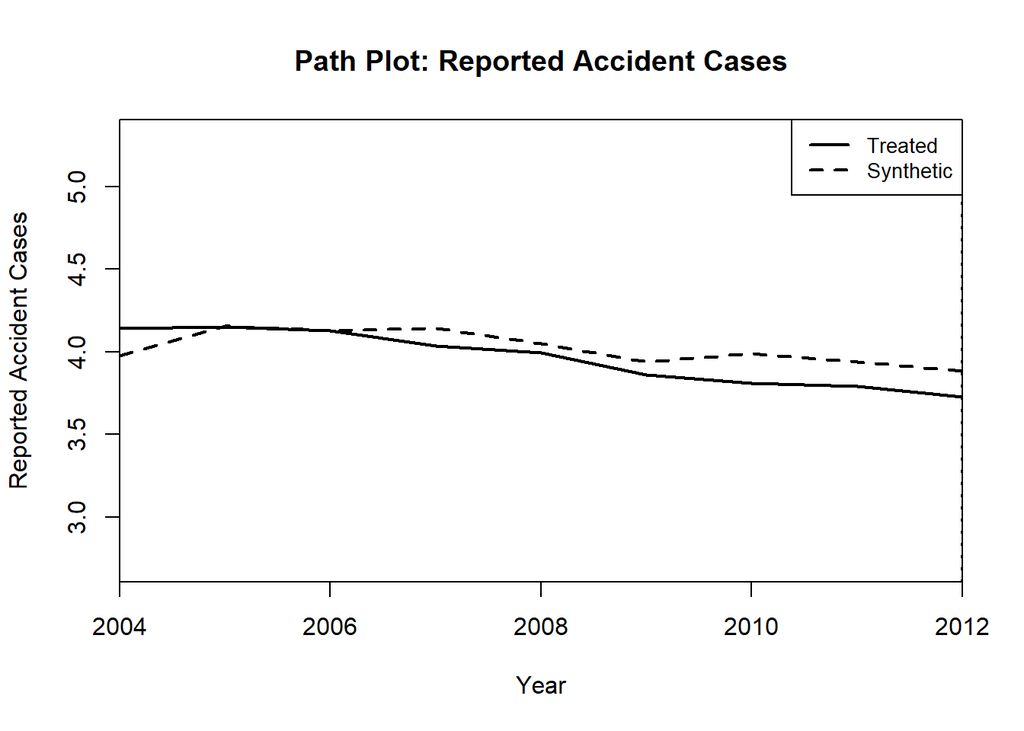

```r
# For Accident Cases
plot_path(
  dp = f_accident_results$dataprep,
  synth_out = f_accident_results$synth_out,
  ylab = "Reported Accident Cases",
  title = "Path Plot: Reported Accident Cases"
)
```

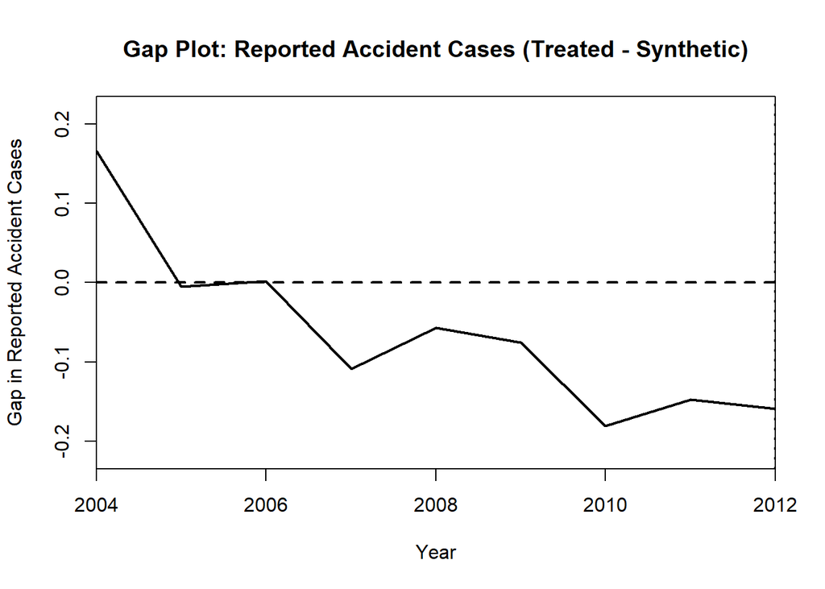

```r
plot_gaps(
  synth.res = f_accident_results$synth_out,
  dataprep.res = f_accident_results$dataprep,
  ylab = "Gap in Reported Accident Cases",
  title = "Gap Plot: Reported Accident Cases (Treated - Synthetic)"
)
```

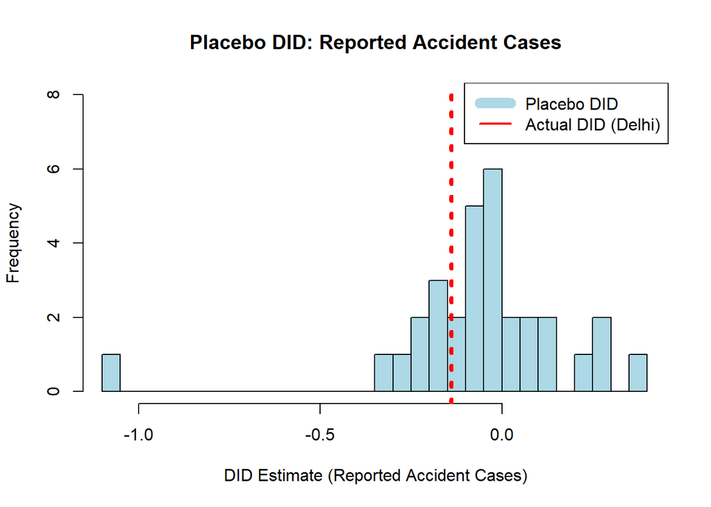

```r
plot_placebo_hist(
  placebo_did = f_placebo_accident$did,
  did_actual = f_accident_results$did,
  xlab = "DID Estimate (Reported Accident Cases)",
  title = "Placebo DID: Reported Accident Cases"
)
```

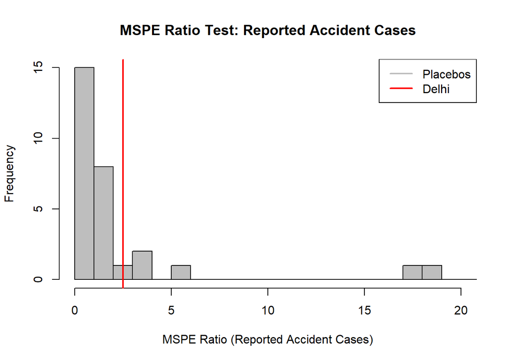

```r
plot_mspe_hist(
  placebo_ratios = f_placebo_accident$mspe_ratio,
  treated_ratio = f_mspe_accident,
  xlab = "MSPE Ratio (Reported Accident Cases)",
  title = "MSPE Ratio Test: Reported Accident Cases",
  xlim = c(0,20)
)
```

#### Estimates for Murder Cases

```r
# Run SCM for MURDERS per 100k
f_murder_results <- run_scm_analysis_f(
  data = df_mod_modified_synth_filtered,
  outcome_var = "MURDERS per 100k"
)
```

```
##
## X1, X0, Z1, Z0 all come directly from dataprep object.
##
##
## ****************
##  searching for synthetic control unit
##
##
## ****************
## ****************
## ****************
##
## MSPE (LOSS V): 0.01120608
##
## solution.v:
##  0.4051632 0.5948123 2.45901e-05
##
## solution.w:
##  0.008528648 0.003643794 0.003202431 0.003883213 0.002393938 4.6321e-06 0.003996133 0.8456061 0.005143969 0.004813489 0.006492522 0.003322137 0.003139168 0.004638494 0.01556446 0.003740206 0.006670005 0.004649253 0.004171029 0.00960283 0.004968595 0.004001544 0.008783661 0.004995186 0.003514139 0…
```

```r
# Run Placebo Tests for MURDERS per 100k (DID + MSPE)
f_placebo_murder <- run_placebo_tests_f(
  data = df_mod_modified_synth_filtered,
  outcome_var = "MURDERS per 100k"
)
```

[output not shown]

[output cut: 564 more lines]

[output not shown]

```r
# Calculate MSPE Ratio for Delhi (murder)
f_mspe_murder <- calculate_mspe_ratio(
  dp = f_murder_results$dataprep,
  synth_out = f_murder_results$synth_out,
  pre_treatment = f_murder_results$pre_treatment,
  post_treatment = f_murder_results$post_treatment
)

# Calculate p-values
f_p_did_murder <- mean(f_placebo_murder$did >= f_murder_results$did)
f_p_mspe_murder <- mean(f_placebo_murder$mspe_ratio >= f_mspe_murder)

cat("Murder Analysis:\n",
    "DID Estimate:", f_murder_results$did, "\n",
    "DID p-value:", f_p_did_murder, "\n",
    "MSPE Ratio:", f_mspe_murder, "\n",
    "MSPE p-value:", f_p_mspe_murder)
```

```
## Murder Analysis:
##  DID Estimate: -0.01268742
##  DID p-value: 0.7096774
##  MSPE Ratio: 1.36925
##  MSPE p-value: 0.3870968
```

##### Plots for Murders

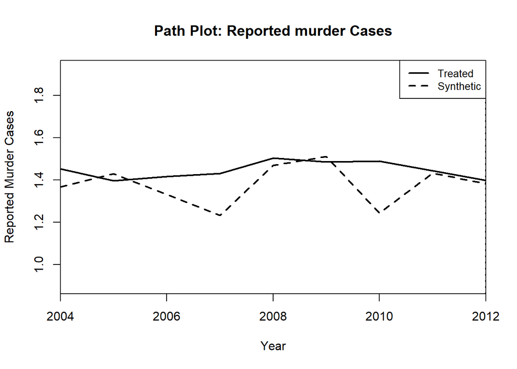

```r
# For Murder Cases
plot_path(
  dp = f_murder_results$dataprep,
  synth_out = f_murder_results$synth_out,
  ylab = "Reported Murder Cases",
  title = "Path Plot: Reported murder Cases"
)
```

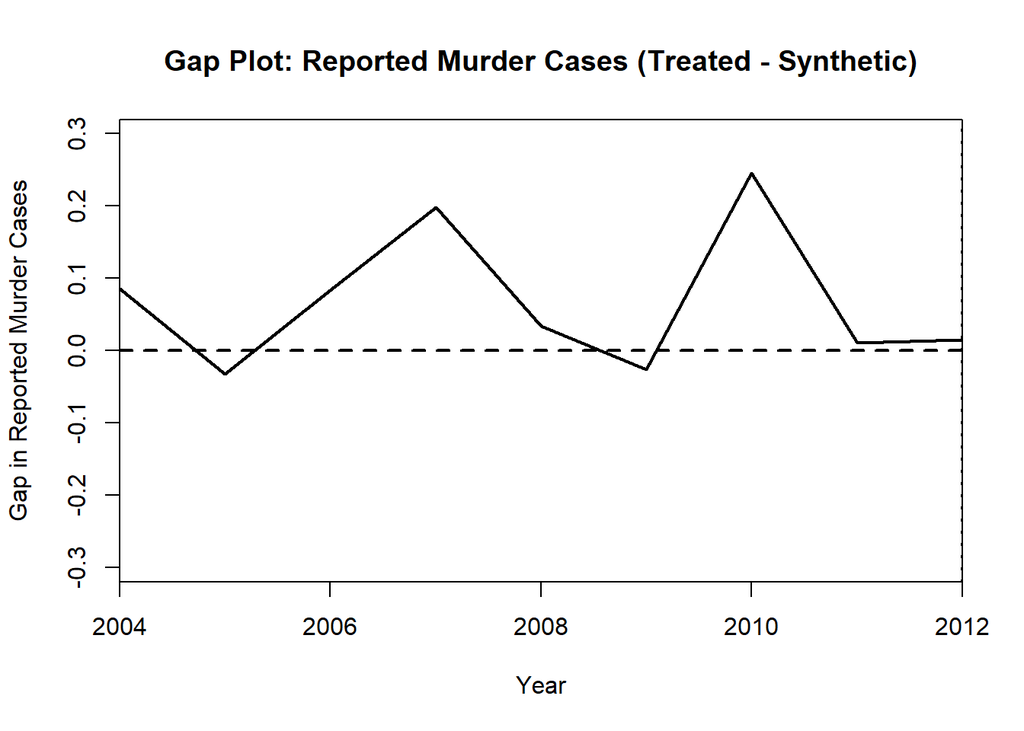

```r
plot_gaps(
  synth.res = f_murder_results$synth_out,
  dataprep.res = f_murder_results$dataprep,
  ylab = "Gap in Reported Murder Cases",
  title = "Gap Plot: Reported Murder Cases (Treated - Synthetic)"
)
```

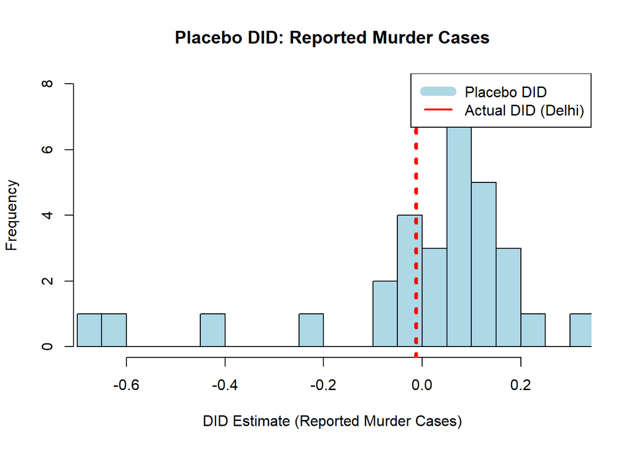

```r
plot_placebo_hist(
  placebo_did = f_placebo_murder$did,
  did_actual = f_murder_results$did,
  xlab = "DID Estimate (Reported Murder Cases)",
  title = "Placebo DID: Reported Murder Cases"
)
```

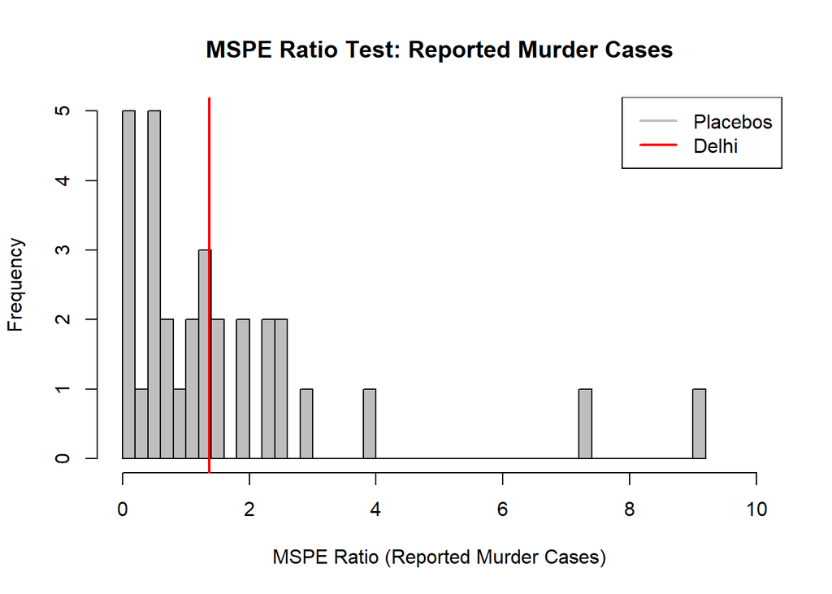

```r
plot_mspe_hist(
  placebo_ratios = f_placebo_murder$mspe_ratio,
  treated_ratio = f_mspe_murder,
  xlab = "MSPE Ratio (Reported Murder Cases)",
  title = "MSPE Ratio Test: Reported Murder Cases",
  xlim = c(0,10)
)
```

## XXXX End of Fake time Treatment Check XXXX

### XXXX End of Complete Analysis XXXX